# planteamiento del proyecto

Angel Santiago Barrantes Montoya

2026-09-26

# Proyecto: Modelación estadística para inversiones de corto plazo

## 1. Planteamiento del problema

Una serie de precios bursátiles no es una muestra de observaciones independientes e idénticamente distribuidas. Es la realización de un proceso estocástico cuyo nivel no es estacionario: la media y la varianza del precio dependen del momento en que se observen, de modo que estadísticos como el promedio o la desviación estándar del precio carecen de interpretación estable. Esta es la primera dificultad práctica que enfrenta cualquier análisis financiero aplicado, y la que obliga a trabajar no sobre el precio sino sobre una transformación suya.

La transformación habitual es el rendimiento logarítmico, definido como el logaritmo del cociente entre dos cierres consecutivos. Su uso no es arbitrario: estabiliza la varianza, convierte los cambios porcentuales en una escala aditiva en el tiempo y elimina buena parte de la tendencia que hace no estacionario al precio. Sin embargo, resolver el problema del nivel no resuelve el problema de la forma. Los rendimientos financieros presentan de manera sistemática colas más pesadas que las de una distribución normal, agrupamiento de volatilidad —periodos tranquilos seguidos de periodos agitados— y valores extremos que no son errores de medición sino parte legítima del fenómeno. En consecuencia, los estadísticos construidos sobre el supuesto de normalidad, empezando por la media aritmética y el coeficiente de correlación de Pearson, se vuelven frágiles justamente en los tramos que más importan para una decisión de inversión.

A esta dificultad distribucional se suma una de estructura de dependencia. En la práctica financiera se asume que la asociación entre dos activos queda resumida por un coeficiente de correlación lineal, y que un valor cercano a cero autoriza a tratarlos como independientes. Ambas afirmaciones son aproximaciones. La correlación lineal solo captura la componente lineal de la relación; la correlación de rangos amplía el alcance a relaciones monótonas, pero sigue siendo ciega a dependencias que se manifiestan en la magnitud de los movimientos y no en su dirección. Determinar hasta qué punto estas medidas describen adecuadamente la asociación entre activos reales es, en sí mismo, un problema estadístico.

El presente trabajo aborda estas cuestiones en su etapa exploratoria, sobre una muestra construida deliberadamente heterogénea de veintiún instrumentos distribuidos en ocho estratos: acciones (Tesla, Google, Microsoft y Anglo American, esta última como aproximación al mercado del diamante), índices bursátiles (S&P 500, STOXX Europe 600 y Nasdaq-100), materias primas negociadas mediante futuros (petróleo WTI, gas natural, oro, plata y cobre), renta fija (bonos del Tesoro de Estados Unidos a más de veinte años), divisas (índice del dólar y euro), criptoactivos (bitcoin y ethereum), volatilidad implícita (índice VIX) y productos inversos (fondos que replican el movimiento diario contrario del S&P 500, del Nasdaq-100 y del oro). La heterogeneidad es intencional: si los patrones distribucionales y de dependencia que se buscan son propios de los mercados financieros y no de un sector concreto, deben aparecer en clases de activos con mecanismos de formación de precios, liquidez y exposición al ciclo económico distintos entre sí.

Los productos inversos cumplen un papel particular dentro de la muestra. Por construcción, su rendimiento diario es un múltiplo negativo del rendimiento de otro activo que también forma parte del estudio, de modo que su correlación con ese activo debe ser cercana a −1. Funcionan así como casos de control: permiten comprobar que las medidas de asociación empleadas recuperan una dependencia conocida de antemano y, al mismo tiempo, muestran qué ocurre en una cartera cuando se combinan activos con correlación fuertemente negativa.

La obtención de los datos planteó además un problema operativo con consecuencias estadísticas directas. Los veintiún activos no comparten calendario de negociación: los criptoactivos cotizan todos los días del año, los contratos de futuros operan en jornadas en que las bolsas de acciones permanecen cerradas y el índice europeo sigue su propio calendario de festivos. Tampoco comparten la hora de cierre: el STOXX Europe 600 cierra varias horas antes que la bolsa de Nueva York y los criptoactivos cierran a medianoche en tiempo universal. Alinear las series por posición en lugar de por fecha produciría un desfase creciente entre ellas y, con él, coeficientes de asociación carentes de sentido. Este detalle, que rara vez se menciona en los tratamientos introductorios, condiciona toda la sección de correlaciones del informe.

## 2. Pregunta de investigación

¿Qué estructura distribucional y de dependencia presentan los rendimientos diarios de un conjunto heterogéneo de activos financieros, y en qué medida las medidas de asociación basadas en rangos y en distancias describen esa dependencia con mayor fidelidad que los estadísticos clásicos apoyados en supuestos de normalidad y linealidad?

De esta pregunta se desprenden cuatro interrogantes operativos que orientan el análisis:

- ¿Presentan las distintas clases de activos, dentro de una misma ventana temporal, comportamientos distribucionales comparables en cuanto a dispersión, asimetría y presencia de valores atípicos?
- ¿Coinciden las conclusiones sobre la asociación entre activos cuando se emplea un coeficiente sensible únicamente a relaciones monótonas frente a uno capaz de detectar cualquier forma de dependencia?
- ¿Es estable en el tiempo la relación de cada activo con el índice de referencia, o los coeficientes agregados del periodo ocultan regímenes de comportamiento distintos?
- ¿Qué aportan a una cartera los activos con correlación fuertemente negativa, y a qué costo en términos de rendimiento?

## 3. Objetivo general

Caracterizar el comportamiento distribucional y la estructura de dependencia de los rendimientos logarítmicos diarios de una muestra heterogénea de veintiún activos financieros, mediante análisis exploratorio de datos y medidas de asociación robustas a la presencia de valores extremos, tomando el S&P 500 como referencia de mercado para evaluar el desempeño relativo de cada instrumento y el efecto de combinar activos con correlación negativa.

## 4. Objetivos específicos

- Diseñar y ejecutar un procedimiento propio de extracción de información bursátil que garantice trazabilidad y reproducibilidad, y delimitar una ventana muestral común que haga comparables entre sí a los veintiún activos seleccionados.
- Transformar las series de precios en rendimientos logarítmicos y diagnosticar la calidad de cada base en cuanto a tipos de variable, completitud y cardinalidad, identificando las limitaciones que cada activo impone al análisis posterior.
- Cuantificar la presencia de valores atípicos en precios, volumen y rendimientos mediante el criterio de rango intercuartílico, y estimar su efecto sobre las medidas de tendencia central con el fin de justificar el uso de estadísticos robustos.
- Describir la forma de las distribuciones de las variables originales y de los rendimientos a través de histogramas, contrastando el comportamiento de las distintas clases de activos.
- Medir la asociación entre los veintiún activos mediante el coeficiente de correlación de Spearman y la correlación de distancias, comparar ambos resultados para distinguir la dependencia monótona de la dependencia general, e identificar los pares con correlación fuertemente negativa.
- Evaluar el desempeño de cada activo frente al S&P 500 mediante regresión lineal sobre los rendimientos diarios, y examinar la estabilidad temporal de esa relación a través de correlaciones calculadas sobre ventanas móviles.
- Evaluar el resultado de combinar en una misma cartera activos con correlación fuertemente negativa, y contrastarlo con el de combinar activos con correlación cercana a cero, para distinguir entre cubrir y diversificar.

## 5. Justificación

El trabajo se articula sobre los contenidos de tres asignaturas, y conviene explicitar de qué manera interviene cada una.

**Muestreo.** La selección de los veintiún activos no obedece a un procedimiento aleatorio sino a un diseño intencional estratificado por clase de activo, con ocho estratos: acciones, índices bursátiles, materias primas, renta fija, divisas, criptoactivos, volatilidad implícita y productos inversos. Esta decisión tiene una consecuencia que debe declararse: los resultados describen la muestra observada y no admiten inferencia probabilística hacia el universo de instrumentos cotizados, puesto que no existe un marco muestral con probabilidades de selección conocidas. A cambio, el diseño garantiza la presencia de contrastes que un muestreo aleatorio simple difícilmente habría producido con veintiún unidades. Dentro de ese diseño, los productos inversos se incorporaron de forma deliberada como unidades de control, porque su relación con otros activos de la muestra se conoce de antemano. La delimitación de una ventana temporal común cumple una función análoga a la de un control experimental: al obligar a que todos los activos se observen sobre el mismo periodo, se evita que las diferencias entre ellos se confundan con diferencias entre regímenes de mercado.

**Series de tiempo.** El objeto de estudio es una sucesión ordenada de observaciones, no un conjunto intercambiable de ellas, y el orden es informativo. El paso del precio al rendimiento logarítmico es la primera operación propia de la materia: transforma una serie integrada en una aproximadamente estacionaria en media, estabiliza la varianza y permite que los rendimientos de periodos sucesivos se sumen en lugar de multiplicarse, propiedad que se aprovecha directamente al construir las trayectorias acumuladas del informe. El análisis mediante ventanas móviles pertenece igualmente a este ámbito: al recalcular un coeficiente sobre subperiodos consecutivos se abandona el supuesto de parámetros constantes y se abre la puerta a los modelos de dependencia temporal y volatilidad variable que constituyen la continuación natural de este trabajo. La alineación de las series por fecha, y el cálculo de los rendimientos después de alinear los precios, responde a la misma lógica: garantizar que cada observación de un activo corresponda al mismo intervalo de tiempo que la de los demás.

**Estadística no paramétrica.** El diagnóstico de valores atípicos realizado sobre cada base proporciona la justificación empírica del enfoque. Cuando una proporción apreciable de las observaciones cae fuera del rango intercuartílico, y cuando la exclusión de esos puntos desplaza la media de manera sustantiva, los procedimientos que dependen de supuestos distribucionales pierden fiabilidad. Las medidas basadas en rangos, como el coeficiente de Spearman, resuelven parte del problema: al sustituir los valores por su posición ordinal se vuelven invariantes ante transformaciones monótonas y acotan la influencia de los extremos. Pero conservan una limitación importante, y es que un valor nulo no implica independencia. La correlación de distancias supera esa restricción, ya que se anula si y solo si las variables son independientes y detecta por tanto relaciones no lineales que los coeficientes anteriores no registran. Emplear ambas medidas en paralelo no es redundante: su discrepancia es informativa, siempre que se tenga en cuenta que el estimador muestral de la correlación de distancias tiene un sesgo positivo, cuya magnitud se cuantifica en la sección de correlaciones.

La pertinencia práctica del enfoque es directa. Las decisiones de diversificación y las medidas de riesgo de una cartera descansan sobre estimaciones de correlación. Si esas estimaciones se obtienen con un coeficiente que no capta la forma real de la dependencia, o si se asume constante una relación que cambia a lo largo del tiempo, el riesgo efectivamente asumido difiere del riesgo calculado. La inclusión de activos con correlación fuertemente negativa permite además examinar una distinción que suele confundirse en la práctica: diversificar reduce el riesgo sin renunciar al rendimiento, mientras que cubrir reduce el riesgo a costa de anular también el rendimiento. Verificar estos supuestos sobre datos reales, antes de construir cualquier modelo predictivo, es el propósito de esta etapa del proyecto.

## 6. Origen y construcción de los datos

La información procede de Yahoo Finance y fue obtenida mediante un extractor propio desarrollado en Python (`Scrapper multiactivo excel.py`), que consulta el histórico diario completo de cada instrumento, calcula el rendimiento y el rango porcentual de cada jornada, y consolida el resultado en un único archivo de Excel con una hoja por activo. Un segundo procedimiento (`exportar_csv.py`) recorta las series a la ventana común de análisis y las exporta en formato CSV, que es el insumo directo de este informe. Los tickers consultados fueron los siguientes:

| Activo | Ticker | Clase | Mercado |
| --- | --- | --- | --- |
| Tesla | TSLA | Acción | NASDAQ |
| Google (Alphabet) | GOOGL | Acción | NASDAQ |
| Microsoft | MSFT | Acción | NASDAQ |
| Diamante (proxy) | NGLOY | Acción | OTC |
| S&P 500 | ^GSPC | Índice | Estados Unidos |
| STOXX Europe 600 | ^STOXX | Índice | Europa |
| Nasdaq-100 | QQQ | Índice (fondo cotizado) | NASDAQ |
| Petróleo WTI | CL=F | Futuro | NYMEX |
| Gas natural | NG=F | Futuro | NYMEX |
| Oro | GC=F | Futuro | COMEX |
| Plata | SI=F | Futuro | COMEX |
| Cobre | HG=F | Futuro | COMEX |
| Bonos del Tesoro a más de 20 años | TLT | Renta fija (fondo cotizado) | NASDAQ |
| Índice del dólar | DX-Y.NYB | Divisa | ICE |
| Euro | FXE | Divisa (fondo cotizado) | NYSE Arca |
| Bitcoin | BTC-USD | Criptoactivo | Negociación continua |
| Ethereum | ETH-USD | Criptoactivo | Negociación continua |
| VIX | ^VIX | Volatilidad implícita | CBOE |
| Short S&P 500 | SH | Inverso −1x | NYSE Arca |
| Short Nasdaq-100 | PSQ | Inverso −1x | NYSE Arca |
| UltraShort oro | GLL | Inverso −2x | NYSE Arca |

https://finance.yahoo.com/

Sobre la construcción de esta base deben declararse las siguientes decisiones y sus implicaciones.

**Ventana temporal.** El extractor descarga el histórico completo disponible, que abarca desde 1927 en el caso del S&P 500 hasta 2017 en el de ethereum. Comparar series con veinticuatro mil y con tres mil observaciones carece de sentido estadístico, por lo que todas se recortaron a una ventana común de cinco años, del 4 de septiembre de 2021 al 4 de septiembre de 2026. La fecha final queda fija en el procedimiento de exportación, de modo que volver a ejecutar el extractor no altera el periodo analizado. La ventana deja aproximadamente 1.255 observaciones diarias por activo, salvo en los criptoactivos, que suman 1.827 porque cotizan también los fines de semana.

**Alineación por fecha y cálculo de rendimientos.** Como los calendarios de negociación difieren entre mercados, la consolidación de las series se hace cruzando por fecha y no por posición, y se conservan solo las jornadas en que los veintiún activos tienen precio. Los rendimientos del análisis de dependencia se calculan después de esa alineación, sobre los precios de las jornadas comunes. De esta forma el rendimiento de cada activo cubre exactamente el mismo intervalo que el de los demás: el movimiento de un fin de semana del bitcoin, o el de un día en que solo cotizaron los futuros, queda incorporado en el rendimiento de la siguiente jornada común en lugar de perderse.

**Horas de cierre.** Aun con las fechas alineadas, los activos no cierran a la misma hora. El STOXX Europe 600 cierra varias horas antes que la bolsa de Nueva York y los criptoactivos cierran a medianoche en tiempo universal. Parte de lo que ocurre en la tarde estadounidense se refleja al día siguiente en el índice europeo, lo que atenúa su correlación contemporánea con los activos de Estados Unidos. La sección de correlaciones cuantifica este efecto.

**Divisas.** Para el euro se descartó el tipo de cambio EUR/USD que publica Yahoo Finance, porque su serie diaria está fechada con un día de retraso respecto de los mercados estadounidenses: su correlación de Spearman con el índice del dólar resultaba prácticamente nula en la misma fecha (−0,07) y de −0,87 al desplazarla un día. En su lugar se utiliza FXE, un fondo cotizado en Nueva York que replica el euro frente al dólar y cierra a la misma hora que las acciones. Ni el índice del dólar ni el VIX registran volumen de negociación en la fuente, por lo que su columna de volumen vale cero en todas las fechas.

**Precio empleado.** El rendimiento se calcula sobre el precio de cierre y no sobre el cierre ajustado. Los dividendos y los intereses distribuidos quedan fuera, de modo que las rentabilidades acumuladas corresponden a rentabilidad por precio y no a rentabilidad total. La diferencia es despreciable en los futuros, en las divisas y en los criptoactivos, pero subestima el rendimiento de los activos que reparten dividendos, como Microsoft y Anglo American, y sobre todo el del fondo de bonos del Tesoro, que distribuye cada mes los intereses de su cartera. El cierre ajustado tiene además la desventaja de que la fuente lo recalcula cada vez que se paga un nuevo dividendo.

**Futuros continuos.** Los precios del petróleo, el gas natural, el oro, la plata y el cobre corresponden a series continuas que encadenan contratos sucesivos. En el cambio de un contrato al siguiente pueden aparecer saltos que no son movimientos del mercado. La fuente puede además reconstruir la serie completa: entre la primera descarga de este proyecto, el 6 de septiembre de 2026, y la actual, del 21 de septiembre, Yahoo Finance modificó la serie del oro. Sus cierres cambiaron en una mediana de 0,37 % y hasta un máximo de 1,96 %, y su volumen mediano pasó de 344 a cerca de 181.000 contratos, lo que sugiere que la serie pasó a construirse con el contrato más negociado. El informe utiliza la versión vigente.

**Productos inversos y VIX.** SH y PSQ buscan el rendimiento diario opuesto del S&P 500 y del Nasdaq-100, y GLL el doble del rendimiento diario opuesto del oro. Como el objetivo se reajusta cada día, en horizontes largos su rendimiento acumulado no es el opuesto del rendimiento del activo de referencia, y se aleja de él tanto más cuanto mayor es la volatilidad del periodo. El VIX, por su parte, es un índice de volatilidad implícita que no se puede comprar directamente, de modo que su rendimiento es la variación de un indicador y no el resultado de una inversión.

**Aproximación del diamante.** El diamante no cotiza como contrato de futuros en ningún mercado organizado. Su precio se establece mediante catálogos de referencia elaborados por De Beers y por el índice Rapaport, y no mediante un mecanismo continuo de oferta y demanda, por lo que no existe una serie diaria de precios comparable a la de los demás activos. Se emplea en su lugar la acción de Anglo American (NGLOY), empresa propietaria de De Beers. Debe interpretarse, en consecuencia, como una acción del sector minero sujeta al ciclo bursátil y no como el precio del diamante, y los resultados de este instrumento se leen con esa salvedad a lo largo de todo el informe.

## 7. EDA inicial

### Librerías

```r
library(tidyverse)
library(pander)
library(ggplot2)
library(dlookr)
library(energy)
library(ggrepel)
```

## analisis de datos

Para cada uno de los veintiún activos se calcula la rentabilidad del periodo como el logaritmo del cociente entre el cierre actual y el cierre anterior:

$$rentabilidad =
Ln\left(\frac{C_t}{C_{t-1}}\right)$$

Sobre esta variable, y sobre las variables originales de precio y volumen, se ejecuta el diagnóstico de la base (`diagnose`), el diagnóstico de valores atípicos (`diagnose_outlier`) y los histogramas correspondientes.

### Tesla (TSLA)

```r
tesla <- read.csv("datos_csv/TSLA.csv")
pander::pander(head(tesla,10))
```

| Date | Open | High | Low | Close | Adj.Close | Volume |
| --- | --- | --- | --- | --- | --- | --- |
| 2021-09-07 | 246.7 | 253.4 | 246.4 | 251 | 251 | 60119400 |
| 2021-09-08 | 253.9 | 254.8 | 246.9 | 251.3 | 251.3 | 56379000 |
| 2021-09-09 | 251.1 | 254 | 250.5 | 251.6 | 251.6 | 42233100 |
| 2021-09-10 | 253.2 | 254.2 | 244.8 | 245.4 | 245.4 | 45552600 |
| 2021-09-13 | 246.7 | 248.3 | 236.3 | 247.7 | 247.7 | 68857500 |
| 2021-09-14 | 247.5 | 251.5 | 245.5 | 248.2 | 248.2 | 55574700 |
| 2021-09-15 | 248.3 | 252.3 | 246.1 | 251.9 | 251.9 | 46073100 |
| 2021-09-16 | 250.9 | 253 | 249.2 | 252.3 | 252.3 | 41770200 |
| 2021-09-17 | 252.4 | 253.7 | 250 | 253.2 | 253.2 | 84612600 |
| 2021-09-20 | 244.9 | 247.3 | 239.5 | 243.4 | 243.4 | 74273100 |

creamos la rentabilidad del periodo calculada como:

$$rentabilidad =
Ln\left(\frac{C_t}{C_{t-1}}\right)$$

```r
tesla <- tesla |>
  mutate(
    rentabilidad = log(Close / lag(Close))
  )
tesla <- tesla |>
  mutate(
    rent_porcent = round(rentabilidad*100,4)
  )
```

posteriormente de este analisis vamos a realizar el analisis exploratorio de la base.

```r
pander(diagnose(tesla))
```

Table continues below

| variables | types | missing_count | missing_percent | unique_count |
| --- | --- | --- | --- | --- |
| Date | character | 0 | 0 | 1255 |
| Open | numeric | 0 | 0 | 1215 |
| High | numeric | 0 | 0 | 1223 |
| Low | numeric | 0 | 0 | 1230 |
| Close | numeric | 0 | 0 | 1233 |
| Adj.Close | numeric | 0 | 0 | 1233 |
| Volume | integer | 0 | 0 | 1254 |
| rentabilidad | numeric | 1 | 0.07968 | 1255 |
| rent_porcent | numeric | 1 | 0.07968 | 1248 |

| unique_rate |
| --- |
| 1 |
| 0.9681 |
| 0.9745 |
| 0.9801 |
| 0.9825 |
| 0.9825 |
| 0.9992 |
| 1 |
| 0.9944 |

```r
pander(diagnose_outlier(tesla))
```

Table continues below

| variables | outliers_cnt | outliers_ratio | outliers_mean | with_mean |
| --- | --- | --- | --- | --- |
| Open | 0 | 0 | NA | 287.1 |
| High | 0 | 0 | NA | 293.3 |
| Low | 0 | 0 | NA | 280.7 |
| Close | 0 | 0 | NA | 287 |
| Adj.Close | 0 | 0 | NA | 287 |
| Volume | 38 | 3.028 | 216160618 | 95365649 |
| rentabilidad | 45 | 3.586 | -0.0225 | 0.0002745 |
| rent_porcent | 45 | 3.586 | -2.25 | 0.02744 |

| without_mean |
| --- |
| 287.1 |
| 293.3 |
| 280.7 |
| 287 |
| 287 |
| 91593908 |
| 0.001122 |
| 0.1122 |

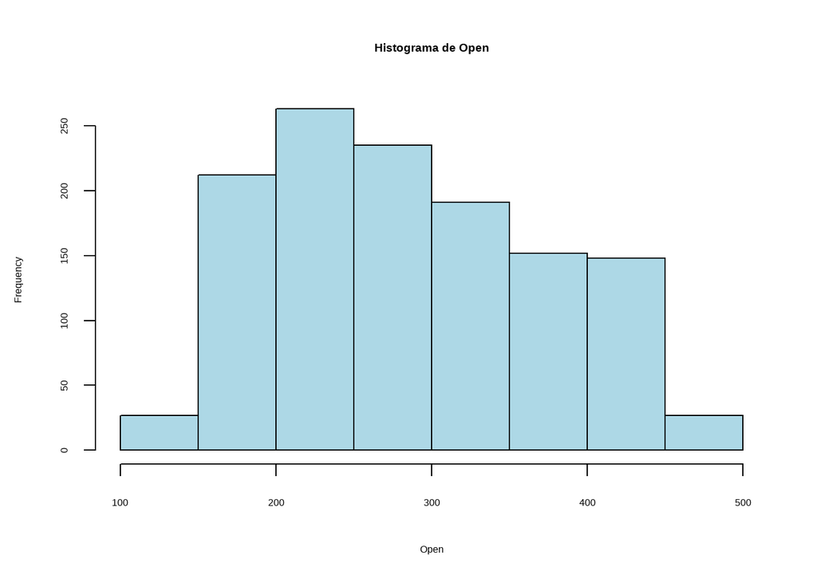

```r
hist(tesla$Open,
     main = "Histograma de Open",
     xlab = "Open",
     col = "lightblue",
     border = "black")
```

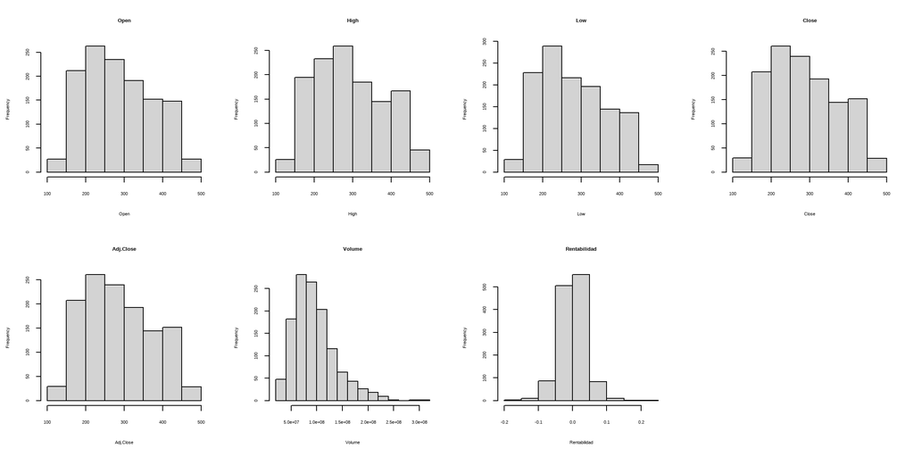

```r
par(mfrow = c(2, 4))

hist(tesla$Open, main = "Open", xlab = "Open")
hist(tesla$High, main = "High", xlab = "High")
hist(tesla$Low, main = "Low", xlab = "Low")
hist(tesla$Close, main = "Close", xlab = "Close")
hist(tesla$Adj.Close, main = "Adj.Close", xlab = "Adj.Close")
hist(tesla$Volume, main = "Volume", xlab = "Volume")
hist(tesla$rentabilidad, main = "Rentabilidad", xlab = "Rentabilidad")

par(mfrow = c(1, 1))
```

### Google - Alphabet (GOOGL)

```r
google <- read.csv("datos_csv/GOOGL.csv")
pander::pander(head(google,10))
```

| Date | Open | High | Low | Close | Adj.Close | Volume |
| --- | --- | --- | --- | --- | --- | --- |
| 2021-09-07 | 143.8 | 144.6 | 143.6 | 144.3 | 142.9 | 20124000 |
| 2021-09-08 | 144.1 | 144.4 | 143 | 143.7 | 142.3 | 18344000 |
| 2021-09-09 | 143.8 | 144.3 | 143.2 | 143.5 | 142.2 | 15314000 |
| 2021-09-10 | 144.2 | 144.7 | 140.7 | 140.9 | 139.5 | 36840000 |
| 2021-09-13 | 141.9 | 142.9 | 141.2 | 142.3 | 141 | 22094000 |
| 2021-09-14 | 143 | 143.4 | 141.8 | 142.5 | 141.2 | 19674000 |
| 2021-09-15 | 142.8 | 144.5 | 141.3 | 144.4 | 143.1 | 27408000 |
| 2021-09-16 | 144 | 144.3 | 142.4 | 143.6 | 142.3 | 26190000 |
| 2021-09-17 | 143 | 143.4 | 140.5 | 140.8 | 139.5 | 53384000 |
| 2021-09-20 | 138.2 | 139 | 136.3 | 138.7 | 137.4 | 46518000 |

creamos la rentabilidad del periodo calculada como:

$$rentabilidad =
Ln\left(\frac{C_t}{C_{t-1}}\right)$$

```r
google <- google |>
  mutate(
    rentabilidad = log(Close / lag(Close))
  )
google <- google |>
  mutate(
    rent_porcent = round(rentabilidad*100,4)
  )
```

posteriormente de este analisis vamos a realizar el analisis exploratorio de la base.

```r
pander(diagnose(google))
```

Table continues below

| variables | types | missing_count | missing_percent | unique_count |
| --- | --- | --- | --- | --- |
| Date | character | 0 | 0 | 1255 |
| Open | numeric | 0 | 0 | 1212 |
| High | numeric | 0 | 0 | 1209 |
| Low | numeric | 0 | 0 | 1218 |
| Close | numeric | 0 | 0 | 1227 |
| Adj.Close | numeric | 0 | 0 | 1237 |
| Volume | integer | 0 | 0 | 1253 |
| rentabilidad | numeric | 1 | 0.07968 | 1254 |
| rent_porcent | numeric | 1 | 0.07968 | 1245 |

| unique_rate |
| --- |
| 1 |
| 0.9657 |
| 0.9633 |
| 0.9705 |
| 0.9777 |
| 0.9857 |
| 0.9984 |
| 0.9992 |
| 0.992 |

```r
pander(diagnose_outlier(google))
```

Table continues below

| variables | outliers_cnt | outliers_ratio | outliers_mean | with_mean |
| --- | --- | --- | --- | --- |
| Open | 196 | 15.62 | 336.8 | 176.9 |
| High | 198 | 15.78 | 340.6 | 179 |
| Low | 196 | 15.62 | 332.6 | 174.8 |
| Close | 194 | 15.46 | 337.6 | 177 |
| Adj.Close | 196 | 15.62 | 336.7 | 176 |
| Volume | 69 | 5.498 | 72861812 | 32417203 |
| rentabilidad | 49 | 3.904 | 0.002557 | 0.0006799 |
| rent_porcent | 49 | 3.904 | 0.2557 | 0.06799 |

| without_mean |
| --- |
| 147.3 |
| 148.8 |
| 145.6 |
| 147.6 |
| 146.2 |
| 30064186 |
| 0.0006036 |
| 0.06036 |

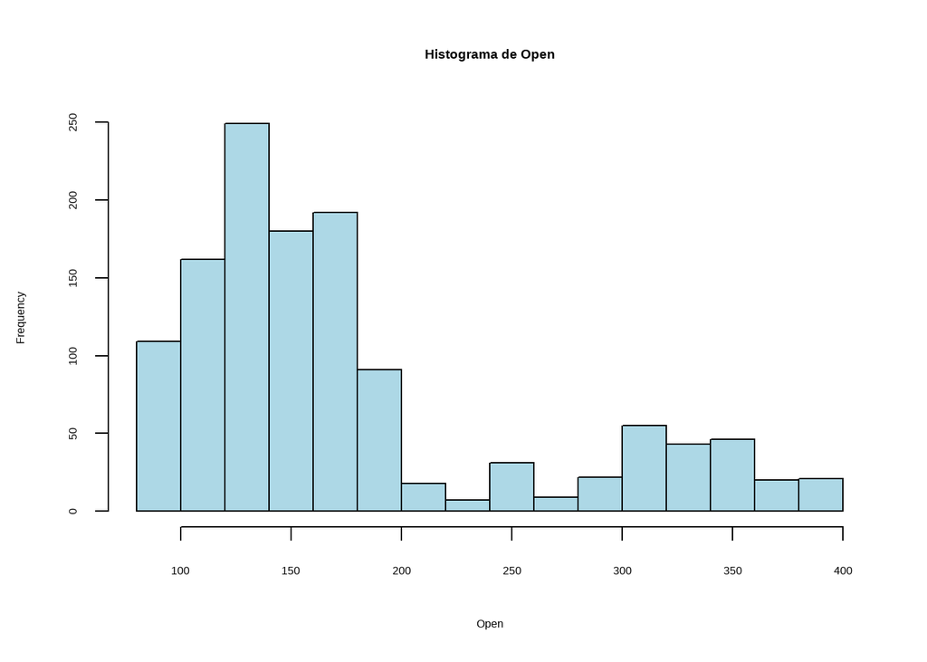

```r
hist(google$Open,
     main = "Histograma de Open",
     xlab = "Open",
     col = "lightblue",
     border = "black")
```

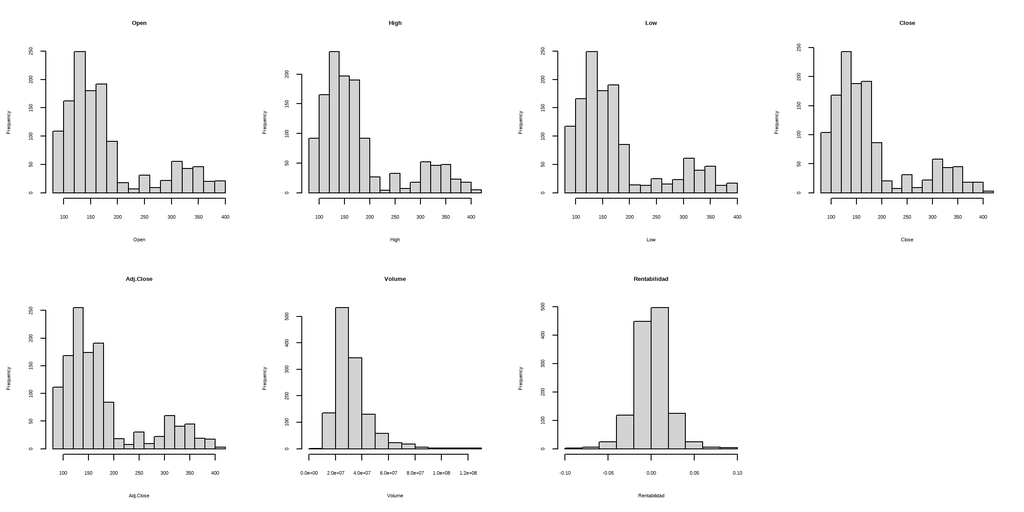

```r
par(mfrow = c(2, 4))

hist(google$Open, main = "Open", xlab = "Open")
hist(google$High, main = "High", xlab = "High")
hist(google$Low, main = "Low", xlab = "Low")
hist(google$Close, main = "Close", xlab = "Close")
hist(google$Adj.Close, main = "Adj.Close", xlab = "Adj.Close")
hist(google$Volume, main = "Volume", xlab = "Volume")
hist(google$rentabilidad, main = "Rentabilidad", xlab = "Rentabilidad")

par(mfrow = c(1, 1))
```

### Microsoft (MSFT)

```r
microsoft <- read.csv("datos_csv/MSFT.csv")
pander::pander(head(microsoft,10))
```

| Date | Open | High | Low | Close | Adj.Close | Volume |
| --- | --- | --- | --- | --- | --- | --- |
| 2021-09-07 | 301 | 301.1 | 298.2 | 300.2 | 288.1 | 17180400 |
| 2021-09-08 | 299.8 | 300.6 | 297.5 | 300.2 | 288.1 | 15046800 |
| 2021-09-09 | 300.8 | 302.1 | 297 | 297.2 | 285.3 | 19927000 |
| 2021-09-10 | 298.4 | 299.9 | 295.4 | 295.7 | 283.8 | 19633400 |
| 2021-09-13 | 297.5 | 298.5 | 294.1 | 297 | 285 | 23652900 |
| 2021-09-14 | 299.6 | 301.4 | 298.1 | 299.8 | 287.7 | 21853400 |
| 2021-09-15 | 303.3 | 305.3 | 301.8 | 304.8 | 292.5 | 28356300 |
| 2021-09-16 | 303.8 | 305.3 | 300.8 | 305.2 | 292.9 | 19550800 |
| 2021-09-17 | 304.2 | 304.5 | 299.5 | 299.9 | 287.8 | 41372500 |
| 2021-09-20 | 296.3 | 298.7 | 289.5 | 294.3 | 282.4 | 38278700 |

creamos la rentabilidad del periodo calculada como:

$$rentabilidad =
Ln\left(\frac{C_t}{C_{t-1}}\right)$$

```r
microsoft <- microsoft |>
  mutate(
    rentabilidad = log(Close / lag(Close))
  )
microsoft <- microsoft |>
  mutate(
    rent_porcent = round(rentabilidad*100,4)
  )
```

posteriormente de este analisis vamos a realizar el analisis exploratorio de la base.

```r
pander(diagnose(microsoft))
```

Table continues below

| variables | types | missing_count | missing_percent | unique_count |
| --- | --- | --- | --- | --- |
| Date | character | 0 | 0 | 1255 |
| Open | numeric | 0 | 0 | 1220 |
| High | numeric | 0 | 0 | 1215 |
| Low | numeric | 0 | 0 | 1214 |
| Close | numeric | 0 | 0 | 1228 |
| Adj.Close | numeric | 0 | 0 | 1247 |
| Volume | integer | 0 | 0 | 1253 |
| rentabilidad | numeric | 1 | 0.07968 | 1255 |
| rent_porcent | numeric | 1 | 0.07968 | 1235 |

| unique_rate |
| --- |
| 1 |
| 0.9721 |
| 0.9681 |
| 0.9673 |
| 0.9785 |
| 0.9936 |
| 0.9984 |
| 1 |
| 0.9841 |

```r
pander(diagnose_outlier(microsoft))
```

Table continues below

| variables | outliers_cnt | outliers_ratio | outliers_mean | with_mean |
| --- | --- | --- | --- | --- |
| Open | 0 | 0 | NA | 371.1 |
| High | 0 | 0 | NA | 374.7 |
| Low | 0 | 0 | NA | 367.4 |
| Close | 0 | 0 | NA | 371.2 |
| Adj.Close | 0 | 0 | NA | 364.4 |
| Volume | 56 | 4.462 | 64841489 | 26892713 |
| rentabilidad | 59 | 4.701 | -0.003202 | 0.0004064 |
| rent_porcent | 59 | 4.701 | -0.3202 | 0.04064 |

| without_mean |
| --- |
| 371.1 |
| 374.7 |
| 367.4 |
| 371.2 |
| 364.4 |
| 25120293 |
| 0.0005846 |
| 0.05846 |

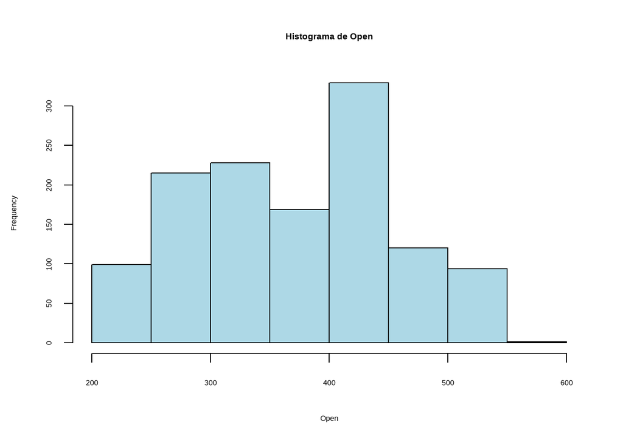

```r
hist(microsoft$Open,
     main = "Histograma de Open",
     xlab = "Open",
     col = "lightblue",
     border = "black")
```

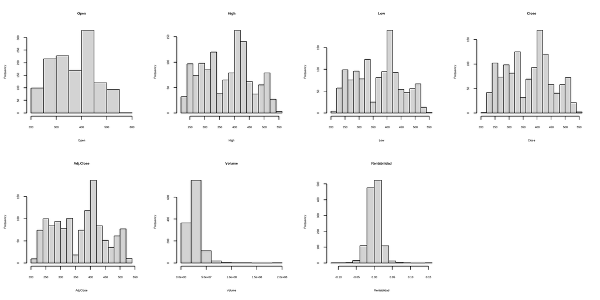

```r
par(mfrow = c(2, 4))

hist(microsoft$Open, main = "Open", xlab = "Open")
hist(microsoft$High, main = "High", xlab = "High")
hist(microsoft$Low, main = "Low", xlab = "Low")
hist(microsoft$Close, main = "Close", xlab = "Close")
hist(microsoft$Adj.Close, main = "Adj.Close", xlab = "Adj.Close")
hist(microsoft$Volume, main = "Volume", xlab = "Volume")
hist(microsoft$rentabilidad, main = "Rentabilidad", xlab = "Rentabilidad")

par(mfrow = c(1, 1))
```

### Petróleo WTI (CL=F)

```r
petroleo <- read.csv("datos_csv/PETROLEO.csv")
pander::pander(head(petroleo,10))
```

| Date | Open | High | Low | Close | Adj.Close | Volume |
| --- | --- | --- | --- | --- | --- | --- |
| 2021-09-07 | 69.11 | 69.48 | 67.64 | 68.35 | 68.35 | 481704 |
| 2021-09-08 | 68.37 | 69.75 | 68.31 | 69.3 | 69.3 | 389325 |
| 2021-09-09 | 69.36 | 69.89 | 67.56 | 68.14 | 68.14 | 556451 |
| 2021-09-10 | 67.97 | 69.96 | 67.68 | 69.72 | 69.72 | 411079 |
| 2021-09-13 | 69.74 | 70.97 | 69.51 | 70.45 | 70.45 | 390939 |
| 2021-09-14 | 70.64 | 71.22 | 69.98 | 70.46 | 70.46 | 414231 |
| 2021-09-15 | 70.76 | 73.14 | 70.65 | 72.61 | 72.61 | 418665 |
| 2021-09-16 | 72.65 | 72.99 | 71.53 | 72.61 | 72.61 | 298412 |
| 2021-09-17 | 72.62 | 72.72 | 71.21 | 71.97 | 71.97 | 119933 |
| 2021-09-20 | 71.92 | 72.08 | 69.86 | 70.29 | 70.29 | 75837 |

creamos la rentabilidad del periodo calculada como:

$$rentabilidad =
Ln\left(\frac{C_t}{C_{t-1}}\right)$$

```r
petroleo <- petroleo |>
  mutate(
    rentabilidad = log(Close / lag(Close))
  )
petroleo <- petroleo |>
  mutate(
    rent_porcent = round(rentabilidad*100,4)
  )
```

posteriormente de este analisis vamos a realizar el analisis exploratorio de la base.

```r
pander(diagnose(petroleo))
```

Table continues below

| variables | types | missing_count | missing_percent | unique_count |
| --- | --- | --- | --- | --- |
| Date | character | 0 | 0 | 1257 |
| Open | numeric | 0 | 0 | 1090 |
| High | numeric | 0 | 0 | 1078 |
| Low | numeric | 0 | 0 | 1090 |
| Close | numeric | 0 | 0 | 1083 |
| Adj.Close | numeric | 0 | 0 | 1083 |
| Volume | integer | 0 | 0 | 1247 |
| rentabilidad | numeric | 1 | 0.07955 | 1251 |
| rent_porcent | numeric | 1 | 0.07955 | 1241 |

| unique_rate |
| --- |
| 1 |
| 0.8671 |
| 0.8576 |
| 0.8671 |
| 0.8616 |
| 0.8616 |
| 0.992 |
| 0.9952 |
| 0.9873 |

```r
pander(diagnose_outlier(petroleo))
```

Table continues below

| variables | outliers_cnt | outliers_ratio | outliers_mean | with_mean |
| --- | --- | --- | --- | --- |
| Open | 47 | 3.739 | 114 | 78.61 |
| High | 56 | 4.455 | 115.9 | 80.07 |
| Low | 46 | 3.66 | 110.8 | 77.03 |
| Close | 45 | 3.58 | 114 | 78.54 |
| Adj.Close | 45 | 3.58 | 114 | 78.54 |
| Volume | 79 | 6.285 | 458149 | 313542 |
| rentabilidad | 46 | 3.66 | -0.02161 | 0.0002321 |
| rent_porcent | 46 | 3.66 | -2.161 | 0.02321 |

| without_mean |
| --- |
| 77.23 |
| 78.4 |
| 75.75 |
| 77.23 |
| 77.23 |
| 303844 |
| 0.001062 |
| 0.1062 |

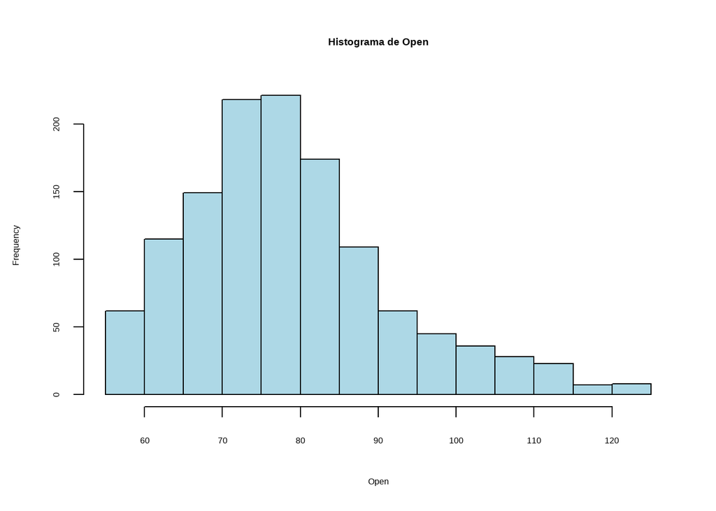

```r
hist(petroleo$Open,
     main = "Histograma de Open",
     xlab = "Open",
     col = "lightblue",
     border = "black")
```

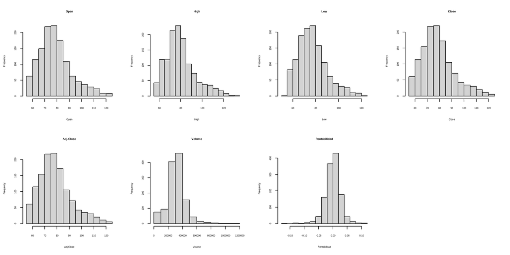

```r
par(mfrow = c(2, 4))

hist(petroleo$Open, main = "Open", xlab = "Open")
hist(petroleo$High, main = "High", xlab = "High")
hist(petroleo$Low, main = "Low", xlab = "Low")
hist(petroleo$Close, main = "Close", xlab = "Close")
hist(petroleo$Adj.Close, main = "Adj.Close", xlab = "Adj.Close")
hist(petroleo$Volume, main = "Volume", xlab = "Volume")
hist(petroleo$rentabilidad, main = "Rentabilidad", xlab = "Rentabilidad")

par(mfrow = c(1, 1))
```

### Gas natural (NG=F)

```r
gas <- read.csv("datos_csv/GASNATURAL.csv")
pander::pander(head(gas,10))
```

| Date | Open | High | Low | Close | Adj.Close | Volume |
| --- | --- | --- | --- | --- | --- | --- |
| 2021-09-07 | 4.71 | 4.774 | 4.557 | 4.568 | 4.568 | 163663 |
| 2021-09-08 | 4.598 | 5.01 | 4.585 | 4.914 | 4.914 | 244742 |
| 2021-09-09 | 4.917 | 5.047 | 4.82 | 5.031 | 5.031 | 234848 |
| 2021-09-10 | 5.002 | 5.058 | 4.913 | 4.938 | 4.938 | 151036 |
| 2021-09-13 | 4.945 | 5.289 | 4.879 | 5.231 | 5.231 | 201770 |
| 2021-09-14 | 5.199 | 5.369 | 5.171 | 5.26 | 5.26 | 200943 |
| 2021-09-15 | 5.28 | 5.65 | 5.266 | 5.46 | 5.46 | 279117 |
| 2021-09-16 | 5.41 | 5.6 | 5.228 | 5.335 | 5.335 | 221139 |
| 2021-09-17 | 5.27 | 5.394 | 5.044 | 5.105 | 5.105 | 164579 |
| 2021-09-20 | 5.015 | 5.172 | 4.905 | 4.985 | 4.985 | 156870 |

creamos la rentabilidad del periodo calculada como:

$$rentabilidad =
Ln\left(\frac{C_t}{C_{t-1}}\right)$$

```r
gas <- gas |>
  mutate(
    rentabilidad = log(Close / lag(Close))
  )
gas <- gas |>
  mutate(
    rent_porcent = round(rentabilidad*100,4)
  )
```

posteriormente de este analisis vamos a realizar el analisis exploratorio de la base.

```r
pander(diagnose(gas))
```

Table continues below

| variables | types | missing_count | missing_percent | unique_count |
| --- | --- | --- | --- | --- |
| Date | character | 0 | 0 | 1258 |
| Open | numeric | 0 | 0 | 1088 |
| High | numeric | 0 | 0 | 1078 |
| Low | numeric | 0 | 0 | 1070 |
| Close | numeric | 0 | 0 | 1083 |
| Adj.Close | numeric | 0 | 0 | 1083 |
| Volume | integer | 0 | 0 | 1246 |
| rentabilidad | numeric | 1 | 0.07949 | 1256 |
| rent_porcent | numeric | 1 | 0.07949 | 1250 |

| unique_rate |
| --- |
| 1 |
| 0.8649 |
| 0.8569 |
| 0.8506 |
| 0.8609 |
| 0.8609 |
| 0.9905 |
| 0.9984 |
| 0.9936 |

```r
pander(diagnose_outlier(gas))
```

Table continues below

| variables | outliers_cnt | outliers_ratio | outliers_mean | with_mean |
| --- | --- | --- | --- | --- |
| Open | 89 | 7.075 | 8.292 | 3.79 |
| High | 90 | 7.154 | 8.59 | 3.918 |
| Low | 89 | 7.075 | 7.976 | 3.663 |
| Close | 87 | 6.916 | 8.314 | 3.785 |
| Adj.Close | 87 | 6.916 | 8.314 | 3.785 |
| Volume | 30 | 2.385 | 262184 | 146075 |
| rentabilidad | 39 | 3.1 | -0.02861 | -0.0003412 |
| rent_porcent | 39 | 3.1 | -2.861 | -0.03411 |

| without_mean |
| --- |
| 3.448 |
| 3.558 |
| 3.335 |
| 3.449 |
| 3.449 |
| 143239 |
| 0.0005641 |
| 0.05641 |

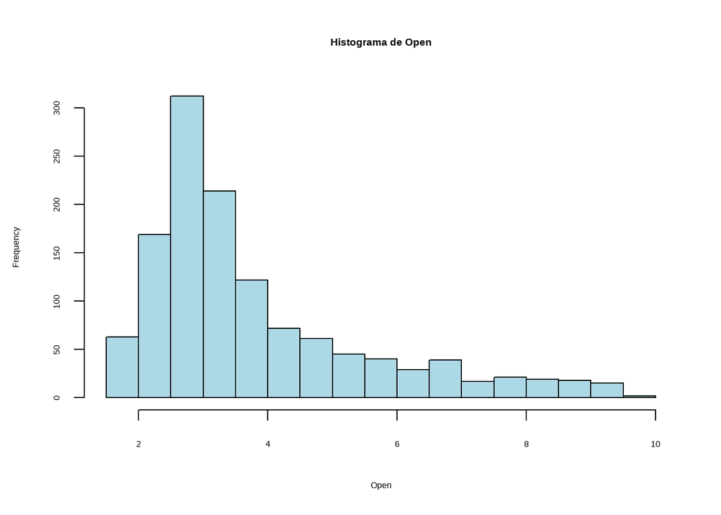

```r
hist(gas$Open,
     main = "Histograma de Open",
     xlab = "Open",
     col = "lightblue",
     border = "black")
```

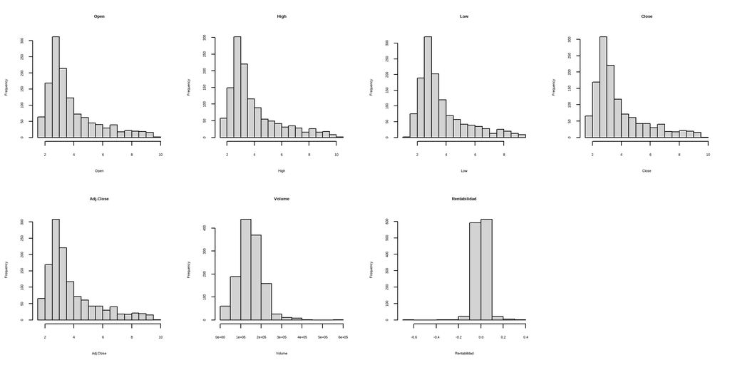

```r
par(mfrow = c(2, 4))

hist(gas$Open, main = "Open", xlab = "Open")
hist(gas$High, main = "High", xlab = "High")
hist(gas$Low, main = "Low", xlab = "Low")
hist(gas$Close, main = "Close", xlab = "Close")
hist(gas$Adj.Close, main = "Adj.Close", xlab = "Adj.Close")
hist(gas$Volume, main = "Volume", xlab = "Volume")
hist(gas$rentabilidad, main = "Rentabilidad", xlab = "Rentabilidad")

par(mfrow = c(1, 1))
```

### Oro (GC=F)

```r
oro <- read.csv("datos_csv/ORO.csv")
pander::pander(head(oro,10))
```

| Date | Open | High | Low | Close | Adj.Close | Volume |
| --- | --- | --- | --- | --- | --- | --- |
| 2021-09-07 | 1834 | 1834 | 1794 | 1798 | 1798 | 252475 |
| 2021-09-08 | 1796 | 1804 | 1783 | 1794 | 1794 | 161258 |
| 2021-09-09 | 1791 | 1803 | 1785 | 1800 | 1800 | 154126 |
| 2021-09-10 | 1796 | 1806 | 1788 | 1792 | 1792 | 136246 |
| 2021-09-13 | 1790 | 1800 | 1784 | 1794 | 1794 | 114310 |
| 2021-09-14 | 1795 | 1811 | 1781 | 1807 | 1807 | 197954 |
| 2021-09-15 | 1807 | 1808 | 1792 | 1795 | 1795 | 139297 |
| 2021-09-16 | 1796 | 1797 | 1746 | 1757 | 1757 | 255267 |
| 2021-09-17 | 1755 | 1768 | 1747 | 1751 | 1751 | 183254 |
| 2021-09-20 | 1754 | 1768 | 1742 | 1764 | 1764 | 152451 |

creamos la rentabilidad del periodo calculada como:

$$rentabilidad =
Ln\left(\frac{C_t}{C_{t-1}}\right)$$

```r
oro <- oro |>
  mutate(
    rentabilidad = log(Close / lag(Close))
  )
oro <- oro |>
  mutate(
    rent_porcent = round(rentabilidad*100,4)
  )
```

posteriormente de este analisis vamos a realizar el analisis exploratorio de la base.

```r
pander(diagnose(oro))
```

Table continues below

| variables | types | missing_count | missing_percent | unique_count |
| --- | --- | --- | --- | --- |
| Date | character | 0 | 0 | 1258 |
| Open | numeric | 0 | 0 | 1189 |
| High | numeric | 0 | 0 | 1207 |
| Low | numeric | 0 | 0 | 1196 |
| Close | numeric | 0 | 0 | 1196 |
| Adj.Close | numeric | 0 | 0 | 1196 |
| Volume | integer | 0 | 0 | 1245 |
| rentabilidad | numeric | 1 | 0.07949 | 1253 |
| rent_porcent | numeric | 1 | 0.07949 | 1231 |

| unique_rate |
| --- |
| 1 |
| 0.9452 |
| 0.9595 |
| 0.9507 |
| 0.9507 |
| 0.9507 |
| 0.9897 |
| 0.996 |
| 0.9785 |

```r
pander(diagnose_outlier(oro))
```

Table continues below

| variables | outliers_cnt | outliers_ratio | outliers_mean | with_mean |
| --- | --- | --- | --- | --- |
| Open | 0 | 0 | NA | 2662 |
| High | 1 | 0.07949 | 5586 | 2687 |
| Low | 0 | 0 | NA | 2637 |
| Close | 0 | 0 | NA | 2663 |
| Adj.Close | 0 | 0 | NA | 2663 |
| Volume | 58 | 4.61 | 265313 | 190655 |
| rentabilidad | 77 | 6.121 | -0.005168 | 0.0007255 |
| rent_porcent | 77 | 6.121 | -0.5168 | 0.07255 |

| without_mean |
| --- |
| 2662 |
| 2685 |
| 2637 |
| 2663 |
| 2663 |
| 187046 |
| 0.00111 |
| 0.111 |

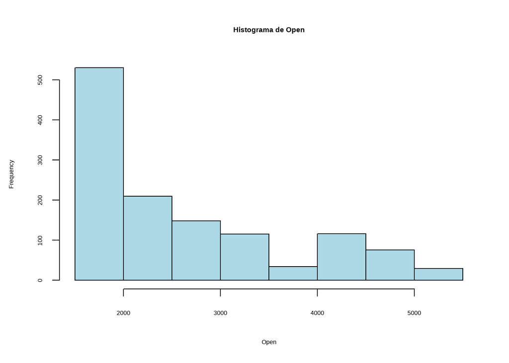

```r
hist(oro$Open,
     main = "Histograma de Open",
     xlab = "Open",
     col = "lightblue",
     border = "black")
```

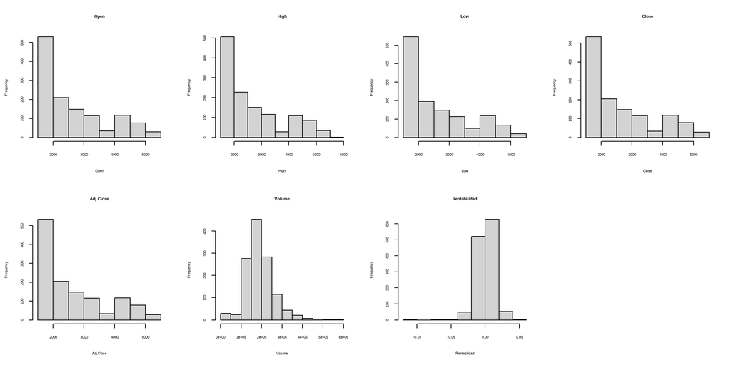

```r
par(mfrow = c(2, 4))

hist(oro$Open, main = "Open", xlab = "Open")
hist(oro$High, main = "High", xlab = "High")
hist(oro$Low, main = "Low", xlab = "Low")
hist(oro$Close, main = "Close", xlab = "Close")
hist(oro$Adj.Close, main = "Adj.Close", xlab = "Adj.Close")
hist(oro$Volume, main = "Volume", xlab = "Volume")
hist(oro$rentabilidad, main = "Rentabilidad", xlab = "Rentabilidad")

par(mfrow = c(1, 1))
```

### Diamante - proxy Anglo American (NGLOY)

```r
diamante <- read.csv("datos_csv/DIAMANTE.csv")
pander::pander(head(diamante,10))
```

| Date | Open | High | Low | Close | Adj.Close | Volume |
| --- | --- | --- | --- | --- | --- | --- |
| 2021-09-07 | 21.22 | 21.3 | 20.86 | 20.88 | 17.7 | 101802 |
| 2021-09-08 | 20.77 | 20.92 | 20.51 | 20.56 | 17.43 | 141375 |
| 2021-09-09 | 20.48 | 20.63 | 20.42 | 20.52 | 17.4 | 139530 |
| 2021-09-10 | 20.93 | 21.09 | 20.72 | 20.73 | 17.57 | 87860 |
| 2021-09-13 | 20.99 | 21.07 | 20.78 | 20.9 | 17.72 | 116053 |
| 2021-09-14 | 20.88 | 20.88 | 20.23 | 20.33 | 17.23 | 140760 |
| 2021-09-15 | 20.09 | 20.21 | 20.04 | 20.17 | 17.1 | 415514 |
| 2021-09-16 | 19.1 | 19.2 | 18.97 | 19.17 | 16.25 | 210166 |
| 2021-09-17 | 18.14 | 18.14 | 17.43 | 17.62 | 14.93 | 211089 |
| 2021-09-20 | 16.4 | 16.81 | 16.34 | 16.8 | 14.24 | 717537 |

creamos la rentabilidad del periodo calculada como:

$$rentabilidad =
Ln\left(\frac{C_t}{C_{t-1}}\right)$$

```r
diamante <- diamante |>
  mutate(
    rentabilidad = log(Close / lag(Close))
  )
diamante <- diamante |>
  mutate(
    rent_porcent = round(rentabilidad*100,4)
  )
```

posteriormente de este analisis vamos a realizar el analisis exploratorio de la base.

```r
pander(diagnose(diamante))
```

Table continues below

| variables | types | missing_count | missing_percent | unique_count |
| --- | --- | --- | --- | --- |
| Date | character | 0 | 0 | 1255 |
| Open | numeric | 0 | 0 | 955 |
| High | numeric | 0 | 0 | 984 |
| Low | numeric | 0 | 0 | 976 |
| Close | numeric | 0 | 0 | 945 |
| Adj.Close | numeric | 0 | 0 | 1114 |
| Volume | integer | 0 | 0 | 1155 |
| rentabilidad | numeric | 1 | 0.07968 | 1243 |
| rent_porcent | numeric | 1 | 0.07968 | 1237 |

| unique_rate |
| --- |
| 1 |
| 0.761 |
| 0.7841 |
| 0.7777 |
| 0.753 |
| 0.8876 |
| 0.9203 |
| 0.9904 |
| 0.9857 |

```r
pander(diagnose_outlier(diamante))
```

Table continues below

| variables | outliers_cnt | outliers_ratio | outliers_mean | with_mean |
| --- | --- | --- | --- | --- |
| Open | 4 | 0.3187 | 28.99 | 17.42 |
| High | 2 | 0.1594 | 29.25 | 17.61 |
| Low | 2 | 0.1594 | 28.69 | 17.23 |
| Close | 4 | 0.3187 | 28.89 | 17.43 |
| Adj.Close | 38 | 3.028 | 27.51 | 16.44 |
| Volume | 86 | 6.853 | 1603129 | 379106 |
| rentabilidad | 41 | 3.267 | 0.01452 | 0.0002443 |
| rent_porcent | 41 | 3.267 | 1.452 | 0.02443 |

| without_mean |
| --- |
| 17.38 |
| 17.59 |
| 17.21 |
| 17.39 |
| 16.09 |
| 289058 |
| -0.0002382 |
| -0.02382 |

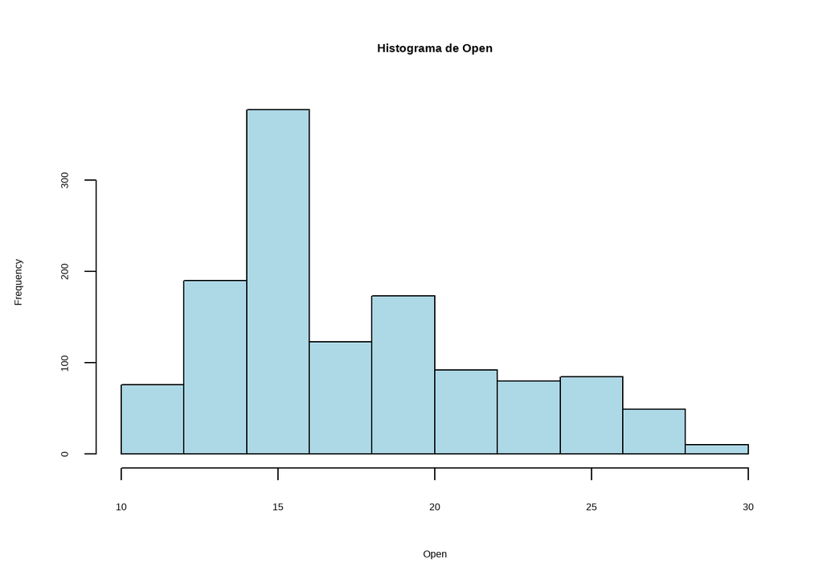

```r
hist(diamante$Open,
     main = "Histograma de Open",
     xlab = "Open",
     col = "lightblue",
     border = "black")
```

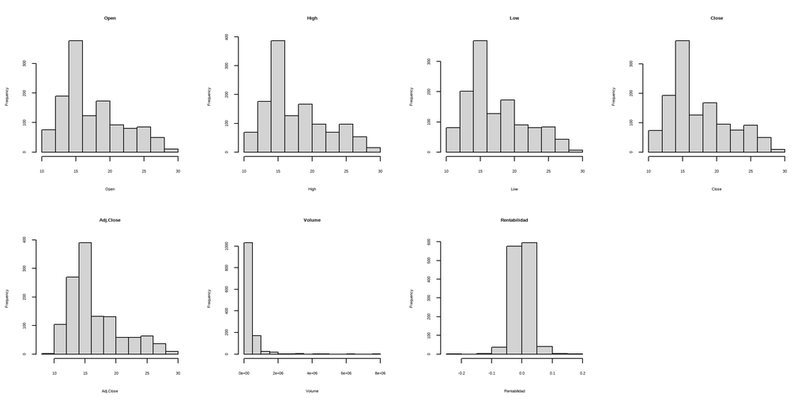

```r
par(mfrow = c(2, 4))

hist(diamante$Open, main = "Open", xlab = "Open")
hist(diamante$High, main = "High", xlab = "High")
hist(diamante$Low, main = "Low", xlab = "Low")
hist(diamante$Close, main = "Close", xlab = "Close")
hist(diamante$Adj.Close, main = "Adj.Close", xlab = "Adj.Close")
hist(diamante$Volume, main = "Volume", xlab = "Volume")
hist(diamante$rentabilidad, main = "Rentabilidad", xlab = "Rentabilidad")

par(mfrow = c(1, 1))
```

### S&P 500 (^GSPC)

```r
sp500 <- read.csv("datos_csv/SP500.csv")
pander::pander(head(sp500,10))
```

| Date | Open | High | Low | Close | Adj.Close | Volume |
| --- | --- | --- | --- | --- | --- | --- |
| 2021-09-07 | 4535 | 4535 | 4513 | 4520 | 4520 | 3.823e+09 |
| 2021-09-08 | 4518 | 4522 | 4494 | 4514 | 4514 | 3.751e+09 |
| 2021-09-09 | 4513 | 4530 | 4492 | 4493 | 4493 | 3.735e+09 |
| 2021-09-10 | 4507 | 4520 | 4458 | 4459 | 4459 | 3.623e+09 |
| 2021-09-13 | 4475 | 4493 | 4446 | 4469 | 4469 | 3.914e+09 |
| 2021-09-14 | 4479 | 4486 | 4435 | 4443 | 4443 | 3.67e+09 |
| 2021-09-15 | 4447 | 4487 | 4438 | 4481 | 4481 | 4.032e+09 |
| 2021-09-16 | 4477 | 4486 | 4444 | 4474 | 4474 | 3.985e+09 |
| 2021-09-17 | 4470 | 4472 | 4428 | 4433 | 4433 | 7.29e+09 |
| 2021-09-20 | 4403 | 4403 | 4306 | 4358 | 4358 | 4.898e+09 |

creamos la rentabilidad del periodo calculada como:

$$rentabilidad =
Ln\left(\frac{C_t}{C_{t-1}}\right)$$

```r
sp500 <- sp500 |>
  mutate(
    rentabilidad = log(Close / lag(Close))
  )
sp500 <- sp500 |>
  mutate(
    rent_porcent = round(rentabilidad*100,4)
  )
```

posteriormente de este analisis vamos a realizar el analisis exploratorio de la base.

```r
pander(diagnose(sp500))
```

Table continues below

| variables | types | missing_count | missing_percent | unique_count |
| --- | --- | --- | --- | --- |
| Date | character | 0 | 0 | 1255 |
| Open | numeric | 0 | 0 | 1254 |
| High | numeric | 0 | 0 | 1251 |
| Low | numeric | 0 | 0 | 1250 |
| Close | numeric | 0 | 0 | 1254 |
| Adj.Close | numeric | 0 | 0 | 1254 |
| Volume | numeric | 0 | 0 | 1255 |
| rentabilidad | numeric | 1 | 0.07968 | 1255 |
| rent_porcent | numeric | 1 | 0.07968 | 1235 |

| unique_rate |
| --- |
| 1 |
| 0.9992 |
| 0.9968 |
| 0.996 |
| 0.9992 |
| 0.9992 |
| 1 |
| 1 |
| 0.9841 |

```r
pander(diagnose_outlier(sp500))
```

Table continues below

| variables | outliers_cnt | outliers_ratio | outliers_mean | with_mean |
| --- | --- | --- | --- | --- |
| Open | 0 | 0 | NA | 5274 |
| High | 0 | 0 | NA | 5303 |
| Low | 0 | 0 | NA | 5243 |
| Close | 0 | 0 | NA | 5275 |
| Adj.Close | 0 | 0 | NA | 5275 |
| Volume | 36 | 2.869 | 7.225e+09 | 4.535e+09 |
| rentabilidad | 56 | 4.462 | -0.004747 | 0.0004267 |
| rent_porcent | 56 | 4.462 | -0.4747 | 0.04267 |

| without_mean |
| --- |
| 5274 |
| 5303 |
| 5243 |
| 5275 |
| 5275 |
| 4.456e+09 |
| 0.0006686 |
| 0.06686 |

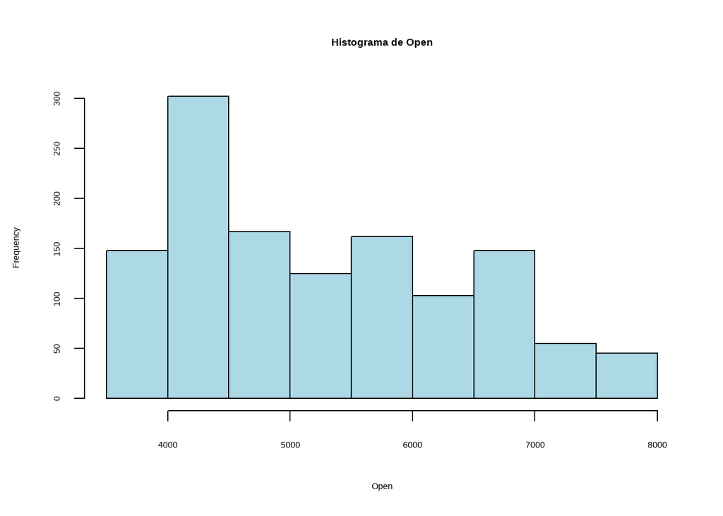

```r
hist(sp500$Open,
     main = "Histograma de Open",
     xlab = "Open",
     col = "lightblue",
     border = "black")
```

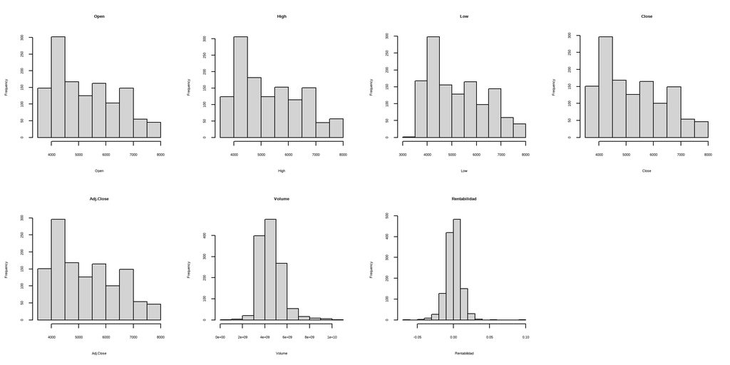

```r
par(mfrow = c(2, 4))

hist(sp500$Open, main = "Open", xlab = "Open")
hist(sp500$High, main = "High", xlab = "High")
hist(sp500$Low, main = "Low", xlab = "Low")
hist(sp500$Close, main = "Close", xlab = "Close")
hist(sp500$Adj.Close, main = "Adj.Close", xlab = "Adj.Close")
hist(sp500$Volume, main = "Volume", xlab = "Volume")
hist(sp500$rentabilidad, main = "Rentabilidad", xlab = "Rentabilidad")

par(mfrow = c(1, 1))
```

### STOXX Europe 600 (^STOXX)

```r
stoxx <- read.csv("datos_csv/STOXX600.csv")
pander::pander(head(stoxx,10))
```

| Date | Open | High | Low | Close | Adj.Close | Volume |
| --- | --- | --- | --- | --- | --- | --- |
| 2021-09-06 | 471.7 | 475.6 | 471.7 | 475.2 | 475.2 | 89335200 |
| 2021-09-07 | 475.1 | 475.1 | 472.6 | 472.9 | 472.9 | 122852800 |
| 2021-09-08 | 472.7 | 472.7 | 466.4 | 467.9 | 467.9 | 163146700 |
| 2021-09-09 | 468.1 | 469.3 | 463.8 | 467.6 | 467.6 | 1.62e+08 |
| 2021-09-10 | 467.7 | 469.1 | 465.8 | 466.3 | 466.3 | 145355900 |
| 2021-09-13 | 466.5 | 470 | 466.5 | 467.7 | 467.7 | 143754800 |
| 2021-09-14 | 467.6 | 469 | 465.7 | 467.6 | 467.6 | 159937700 |
| 2021-09-15 | 467.7 | 468.1 | 463.9 | 463.9 | 463.9 | 189650400 |
| 2021-09-16 | 463.9 | 468 | 463.9 | 466 | 466 | 172691500 |
| 2021-09-17 | 465.9 | 469.8 | 461.3 | 461.8 | 461.8 | 423202300 |

creamos la rentabilidad del periodo calculada como:

$$rentabilidad =
Ln\left(\frac{C_t}{C_{t-1}}\right)$$

```r
stoxx <- stoxx |>
  mutate(
    rentabilidad = log(Close / lag(Close))
  )
stoxx <- stoxx |>
  mutate(
    rent_porcent = round(rentabilidad*100,4)
  )
```

posteriormente de este analisis vamos a realizar el analisis exploratorio de la base.

```r
pander(diagnose(stoxx))
```

Table continues below

| variables | types | missing_count | missing_percent | unique_count |
| --- | --- | --- | --- | --- |
| Date | character | 0 | 0 | 1257 |
| Open | numeric | 0 | 0 | 1203 |
| High | numeric | 0 | 0 | 1202 |
| Low | numeric | 0 | 0 | 1214 |
| Close | numeric | 0 | 0 | 1225 |
| Adj.Close | numeric | 0 | 0 | 1225 |
| Volume | integer | 0 | 0 | 1257 |
| rentabilidad | numeric | 1 | 0.07955 | 1257 |
| rent_porcent | numeric | 1 | 0.07955 | 1224 |

| unique_rate |
| --- |
| 1 |
| 0.957 |
| 0.9562 |
| 0.9658 |
| 0.9745 |
| 0.9745 |
| 1 |
| 1 |
| 0.9737 |

```r
pander(diagnose_outlier(stoxx))
```

Table continues below

| variables | outliers_cnt | outliers_ratio | outliers_mean | with_mean |
| --- | --- | --- | --- | --- |
| Open | 0 | 0 | NA | 504.1 |
| High | 0 | 0 | NA | 506.6 |
| Low | 0 | 0 | NA | 501.6 |
| Close | 0 | 0 | NA | 504.3 |
| Adj.Close | 0 | 0 | NA | 504.3 |
| Volume | 83 | 6.603 | 339533719 | 201401015 |
| rentabilidad | 47 | 3.739 | -0.007953 | 0.0002493 |
| rent_porcent | 47 | 3.739 | -0.7953 | 0.02493 |

| without_mean |
| --- |
| 504.1 |
| 506.6 |
| 501.6 |
| 504.3 |
| 504.3 |
| 191635245 |
| 0.0005681 |
| 0.05681 |

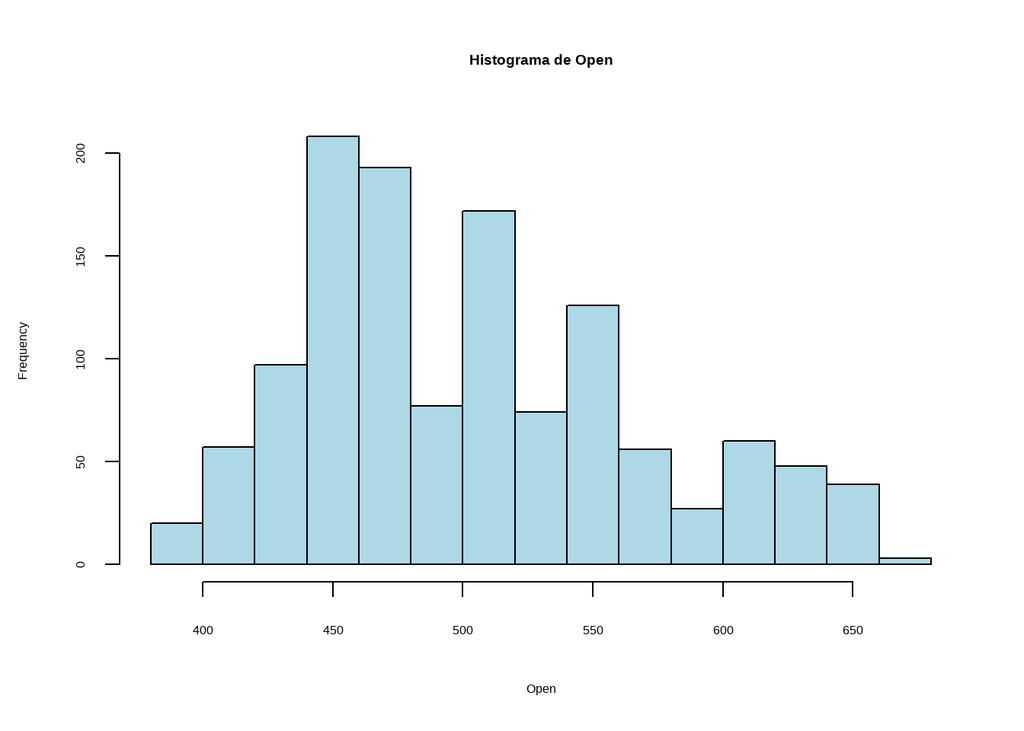

```r
hist(stoxx$Open,
     main = "Histograma de Open",
     xlab = "Open",
     col = "lightblue",
     border = "black")
```

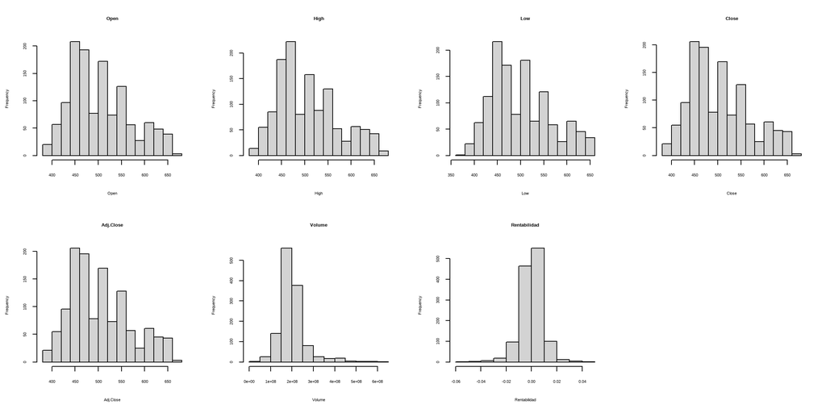

```r
par(mfrow = c(2, 4))

hist(stoxx$Open, main = "Open", xlab = "Open")
hist(stoxx$High, main = "High", xlab = "High")
hist(stoxx$Low, main = "Low", xlab = "Low")
hist(stoxx$Close, main = "Close", xlab = "Close")
hist(stoxx$Adj.Close, main = "Adj.Close", xlab = "Adj.Close")
hist(stoxx$Volume, main = "Volume", xlab = "Volume")
hist(stoxx$rentabilidad, main = "Rentabilidad", xlab = "Rentabilidad")

par(mfrow = c(1, 1))
```

### Nasdaq-100 (QQQ)

```r
qqq <- read.csv("datos_csv/QQQ.csv")
pander::pander(head(qqq,10))
```

| Date | Open | High | Low | Close | Adj.Close | Volume |
| --- | --- | --- | --- | --- | --- | --- |
| 2021-09-07 | 381.7 | 382.8 | 380.5 | 382.1 | 370.8 | 23970200 |
| 2021-09-08 | 381.9 | 381.9 | 378.5 | 380.8 | 369.5 | 32949200 |
| 2021-09-09 | 381 | 382.1 | 379.2 | 379.5 | 368.3 | 29399000 |
| 2021-09-10 | 381.2 | 382 | 376.2 | 376.6 | 365.5 | 40249400 |
| 2021-09-13 | 379 | 379.4 | 374.2 | 376.3 | 365.2 | 48741800 |
| 2021-09-14 | 377.9 | 378.6 | 374.3 | 375.3 | 364.2 | 41826600 |
| 2021-09-15 | 375.7 | 378.4 | 373.4 | 378 | 366.9 | 34097900 |
| 2021-09-16 | 376.7 | 378.9 | 374.7 | 378.3 | 367.1 | 35193100 |
| 2021-09-17 | 377.8 | 377.9 | 372.8 | 373.8 | 362.8 | 60912300 |
| 2021-09-20 | 367.5 | 369.2 | 360.9 | 365.7 | 355.3 | 76203200 |

creamos la rentabilidad del periodo calculada como:

$$rentabilidad =
Ln\left(\frac{C_t}{C_{t-1}}\right)$$

```r
qqq <- qqq |>
  mutate(
    rentabilidad = log(Close / lag(Close))
  )
qqq <- qqq |>
  mutate(
    rent_porcent = round(rentabilidad*100,4)
  )
```

posteriormente de este analisis vamos a realizar el analisis exploratorio de la base.

```r
pander(diagnose(qqq))
```

Table continues below

| variables | types | missing_count | missing_percent | unique_count |
| --- | --- | --- | --- | --- |
| Date | character | 0 | 0 | 1255 |
| Open | numeric | 0 | 0 | 1233 |
| High | numeric | 0 | 0 | 1231 |
| Low | numeric | 0 | 0 | 1239 |
| Close | numeric | 0 | 0 | 1227 |
| Adj.Close | numeric | 0 | 0 | 1246 |
| Volume | integer | 0 | 0 | 1254 |
| rentabilidad | numeric | 1 | 0.07968 | 1255 |
| rent_porcent | numeric | 1 | 0.07968 | 1236 |

| unique_rate |
| --- |
| 1 |
| 0.9825 |
| 0.9809 |
| 0.9873 |
| 0.9777 |
| 0.9928 |
| 0.9992 |
| 1 |
| 0.9849 |

```r
pander(diagnose_outlier(qqq))
```

Table continues below

| variables | outliers_cnt | outliers_ratio | outliers_mean | with_mean |
| --- | --- | --- | --- | --- |
| Open | 0 | 0 | NA | 448.8 |
| High | 0 | 0 | NA | 452.1 |
| Low | 0 | 0 | NA | 445.2 |
| Close | 0 | 0 | NA | 448.9 |
| Adj.Close | 0 | 0 | NA | 443.7 |
| Volume | 41 | 3.267 | 116528185 | 51105507 |
| rentabilidad | 49 | 3.904 | -0.008781 | 0.0005041 |
| rent_porcent | 49 | 3.904 | -0.8781 | 0.05041 |

| without_mean |
| --- |
| 448.8 |
| 452.1 |
| 445.2 |
| 448.9 |
| 443.7 |
| 48896010 |
| 0.0008816 |
| 0.08816 |

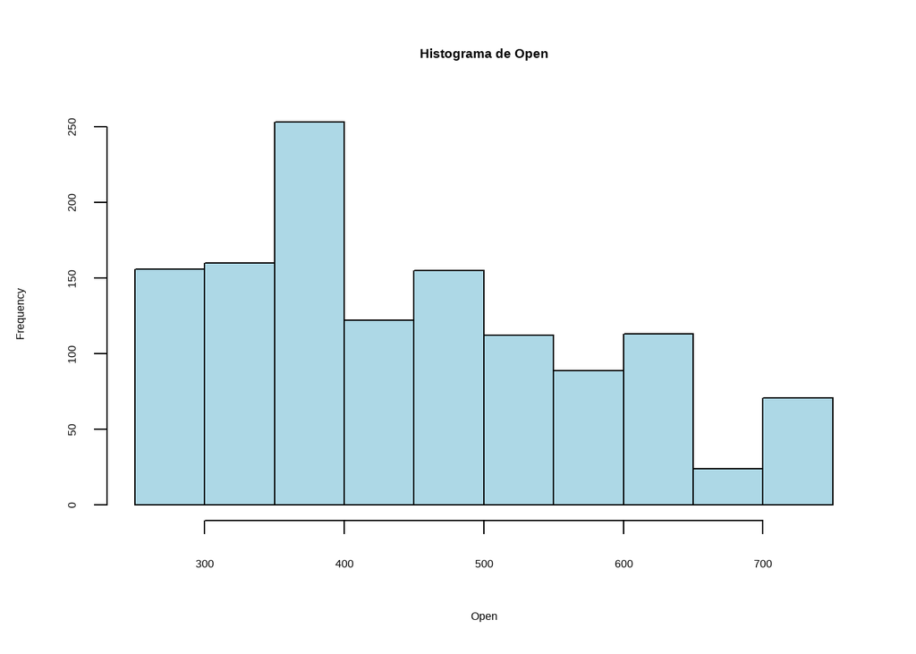

```r
hist(qqq$Open,
     main = "Histograma de Open",
     xlab = "Open",
     col = "lightblue",
     border = "black")
```

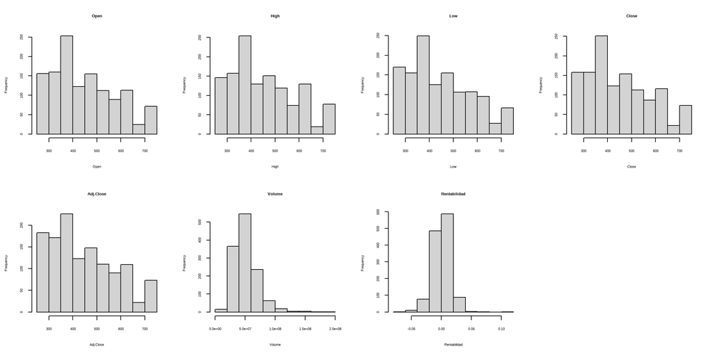

```r
par(mfrow = c(2, 4))

hist(qqq$Open, main = "Open", xlab = "Open")
hist(qqq$High, main = "High", xlab = "High")
hist(qqq$Low, main = "Low", xlab = "Low")
hist(qqq$Close, main = "Close", xlab = "Close")
hist(qqq$Adj.Close, main = "Adj.Close", xlab = "Adj.Close")
hist(qqq$Volume, main = "Volume", xlab = "Volume")
hist(qqq$rentabilidad, main = "Rentabilidad", xlab = "Rentabilidad")

par(mfrow = c(1, 1))
```

### Plata (SI=F)

```r
plata <- read.csv("datos_csv/PLATA.csv")
pander::pander(head(plata,10))
```

| Date | Open | High | Low | Close | Adj.Close | Volume |
| --- | --- | --- | --- | --- | --- | --- |
| 2021-09-07 | 24.81 | 24.81 | 24.18 | 24.33 | 24.33 | 32 |
| 2021-09-08 | 24.35 | 24.4 | 23.94 | 24.01 | 24.01 | 105 |
| 2021-09-09 | 23.95 | 24.24 | 23.84 | 24.13 | 24.13 | 104 |
| 2021-09-10 | 24.14 | 24.14 | 23.85 | 23.85 | 23.85 | 13 |
| 2021-09-13 | 23.69 | 23.75 | 23.33 | 23.75 | 23.75 | 184 |
| 2021-09-14 | 23.66 | 23.85 | 23.64 | 23.84 | 23.84 | 82 |
| 2021-09-15 | 23.8 | 23.8 | 23.76 | 23.76 | 23.76 | 25 |
| 2021-09-16 | 23.51 | 23.51 | 22.61 | 22.75 | 22.75 | 75 |
| 2021-09-17 | 22.89 | 22.91 | 22.3 | 22.3 | 22.3 | 74 |
| 2021-09-20 | 22.38 | 22.38 | 22.14 | 22.16 | 22.16 | 132 |

creamos la rentabilidad del periodo calculada como:

$$rentabilidad =
Ln\left(\frac{C_t}{C_{t-1}}\right)$$

```r
plata <- plata |>
  mutate(
    rentabilidad = log(Close / lag(Close))
  )
plata <- plata |>
  mutate(
    rent_porcent = round(rentabilidad*100,4)
  )
```

posteriormente de este analisis vamos a realizar el analisis exploratorio de la base.

```r
pander(diagnose(plata))
```

Table continues below

| variables | types | missing_count | missing_percent | unique_count |
| --- | --- | --- | --- | --- |
| Date | character | 0 | 0 | 1257 |
| Open | numeric | 0 | 0 | 1126 |
| High | numeric | 0 | 0 | 1149 |
| Low | numeric | 0 | 0 | 1145 |
| Close | numeric | 0 | 0 | 1217 |
| Adj.Close | numeric | 0 | 0 | 1217 |
| Volume | integer | 0 | 0 | 476 |
| rentabilidad | numeric | 1 | 0.07955 | 1257 |
| rent_porcent | numeric | 1 | 0.07955 | 1243 |

| unique_rate |
| --- |
| 1 |
| 0.8958 |
| 0.9141 |
| 0.9109 |
| 0.9682 |
| 0.9682 |
| 0.3787 |
| 1 |
| 0.9889 |

```r
pander(diagnose_outlier(plata))
```

Table continues below

| variables | outliers_cnt | outliers_ratio | outliers_mean | with_mean |
| --- | --- | --- | --- | --- |
| Open | 192 | 15.27 | 72.94 | 34.25 |
| High | 193 | 15.35 | 74.2 | 34.62 |
| Low | 192 | 15.27 | 71.41 | 33.84 |
| Close | 193 | 15.35 | 72.67 | 34.21 |
| Adj.Close | 193 | 15.35 | 72.67 | 34.21 |
| Volume | 152 | 12.09 | 9793 | 1273 |
| rentabilidad | 71 | 5.648 | -0.002239 | 0.000795 |
| rent_porcent | 71 | 5.648 | -0.2239 | 0.0795 |

| without_mean |
| --- |
| 27.27 |
| 27.44 |
| 27.07 |
| 27.24 |
| 27.24 |
| 100.5 |
| 0.0009768 |
| 0.09768 |

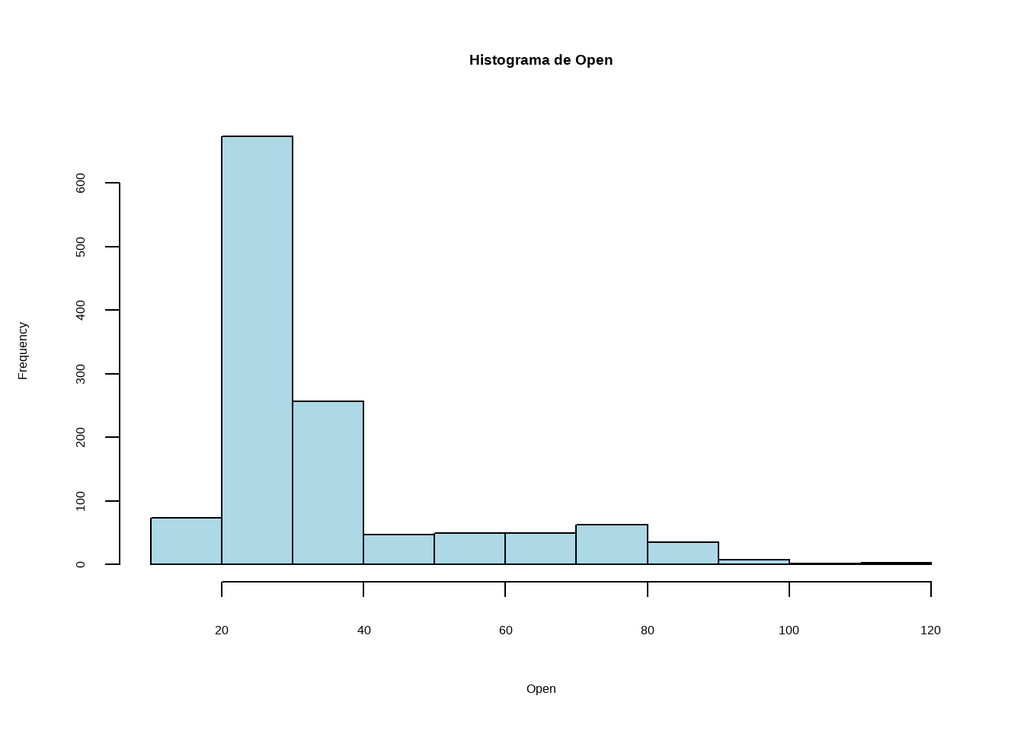

```r
hist(plata$Open,
     main = "Histograma de Open",
     xlab = "Open",
     col = "lightblue",
     border = "black")
```

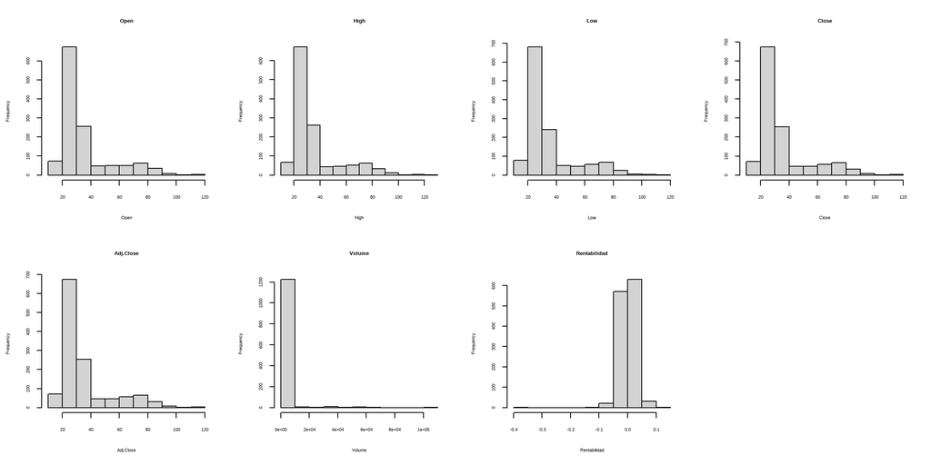

```r
par(mfrow = c(2, 4))

hist(plata$Open, main = "Open", xlab = "Open")
hist(plata$High, main = "High", xlab = "High")
hist(plata$Low, main = "Low", xlab = "Low")
hist(plata$Close, main = "Close", xlab = "Close")
hist(plata$Adj.Close, main = "Adj.Close", xlab = "Adj.Close")
hist(plata$Volume, main = "Volume", xlab = "Volume")
hist(plata$rentabilidad, main = "Rentabilidad", xlab = "Rentabilidad")

par(mfrow = c(1, 1))
```

### Cobre (HG=F)

```r
cobre <- read.csv("datos_csv/COBRE.csv")
pander::pander(head(cobre,10))
```

| Date | Open | High | Low | Close | Adj.Close | Volume |
| --- | --- | --- | --- | --- | --- | --- |
| 2021-09-07 | 4.338 | 4.338 | 4.253 | 4.278 | 4.278 | 746 |
| 2021-09-08 | 4.268 | 4.291 | 4.208 | 4.232 | 4.232 | 929 |
| 2021-09-09 | 4.228 | 4.302 | 4.224 | 4.284 | 4.284 | 645 |
| 2021-09-10 | 4.275 | 4.462 | 4.275 | 4.448 | 4.448 | 904 |
| 2021-09-13 | 4.415 | 4.467 | 4.335 | 4.364 | 4.364 | 630 |
| 2021-09-14 | 4.357 | 4.363 | 4.284 | 4.318 | 4.318 | 505 |
| 2021-09-15 | 4.31 | 4.416 | 4.292 | 4.404 | 4.404 | 624 |
| 2021-09-16 | 4.4 | 4.402 | 4.26 | 4.279 | 4.279 | 589 |
| 2021-09-17 | 4.282 | 4.34 | 4.233 | 4.246 | 4.246 | 808 |
| 2021-09-20 | 4.23 | 4.23 | 4.1 | 4.117 | 4.117 | 759 |

creamos la rentabilidad del periodo calculada como:

$$rentabilidad =
Ln\left(\frac{C_t}{C_{t-1}}\right)$$

```r
cobre <- cobre |>
  mutate(
    rentabilidad = log(Close / lag(Close))
  )
cobre <- cobre |>
  mutate(
    rent_porcent = round(rentabilidad*100,4)
  )
```

posteriormente de este analisis vamos a realizar el analisis exploratorio de la base.

```r
pander(diagnose(cobre))
```

Table continues below

| variables | types | missing_count | missing_percent | unique_count |
| --- | --- | --- | --- | --- |
| Date | character | 0 | 0 | 1258 |
| Open | numeric | 0 | 0 | 1069 |
| High | numeric | 0 | 0 | 1089 |
| Low | numeric | 0 | 0 | 1053 |
| Close | numeric | 0 | 0 | 1089 |
| Adj.Close | numeric | 0 | 0 | 1089 |
| Volume | integer | 0 | 0 | 817 |
| rentabilidad | numeric | 1 | 0.07949 | 1253 |
| rent_porcent | numeric | 1 | 0.07949 | 1238 |

| unique_rate |
| --- |
| 1 |
| 0.8498 |
| 0.8657 |
| 0.837 |
| 0.8657 |
| 0.8657 |
| 0.6494 |
| 0.996 |
| 0.9841 |

```r
pander(diagnose_outlier(cobre))
```

Table continues below

| variables | outliers_cnt | outliers_ratio | outliers_mean | with_mean |
| --- | --- | --- | --- | --- |
| Open | 71 | 5.644 | 6.443 | 4.487 |
| High | 74 | 5.882 | 6.472 | 4.52 |
| Low | 84 | 6.677 | 6.356 | 4.453 |
| Close | 72 | 5.723 | 6.439 | 4.489 |
| Adj.Close | 72 | 5.723 | 6.439 | 4.489 |
| Volume | 94 | 7.472 | 11121 | 1455 |
| rentabilidad | 36 | 2.862 | -0.01161 | 0.0003447 |
| rent_porcent | 36 | 2.862 | -1.161 | 0.03447 |

| without_mean |
| --- |
| 4.37 |
| 4.398 |
| 4.317 |
| 4.37 |
| 4.37 |
| 674.4 |
| 0.0006971 |
| 0.06971 |

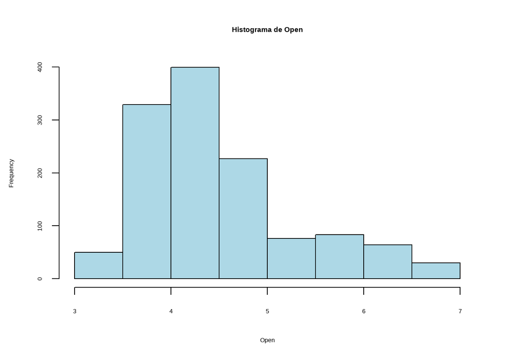

```r
hist(cobre$Open,
     main = "Histograma de Open",
     xlab = "Open",
     col = "lightblue",
     border = "black")
```

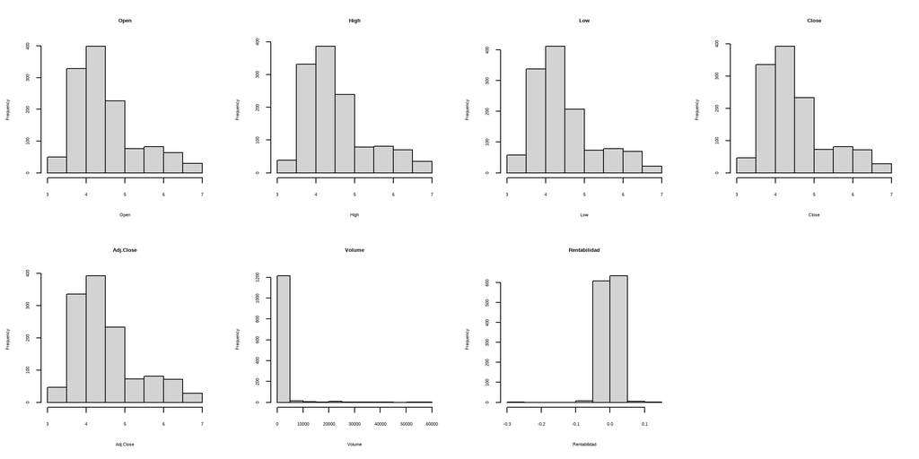

```r
par(mfrow = c(2, 4))

hist(cobre$Open, main = "Open", xlab = "Open")
hist(cobre$High, main = "High", xlab = "High")
hist(cobre$Low, main = "Low", xlab = "Low")
hist(cobre$Close, main = "Close", xlab = "Close")
hist(cobre$Adj.Close, main = "Adj.Close", xlab = "Adj.Close")
hist(cobre$Volume, main = "Volume", xlab = "Volume")
hist(cobre$rentabilidad, main = "Rentabilidad", xlab = "Rentabilidad")

par(mfrow = c(1, 1))
```

### Bonos del Tesoro a más de 20 años (TLT)

```r
tlt <- read.csv("datos_csv/TLT.csv")
pander::pander(head(tlt,10))
```

| Date | Open | High | Low | Close | Adj.Close | Volume |
| --- | --- | --- | --- | --- | --- | --- |
| 2021-09-07 | 147.3 | 147.5 | 146.7 | 146.9 | 123.2 | 15547800 |
| 2021-09-08 | 147.7 | 148.2 | 147.4 | 147.9 | 124 | 14533700 |
| 2021-09-09 | 148.2 | 149.9 | 147.9 | 149.7 | 125.5 | 20324600 |
| 2021-09-10 | 148.9 | 149.2 | 148.2 | 148.4 | 124.4 | 14894600 |
| 2021-09-13 | 149 | 149.5 | 148.9 | 149.3 | 125.2 | 15036100 |
| 2021-09-14 | 149.7 | 151.6 | 149.6 | 151.1 | 126.7 | 19918400 |
| 2021-09-15 | 151.2 | 151.2 | 149.9 | 150.6 | 126.2 | 11940300 |
| 2021-09-16 | 149.7 | 150.4 | 149.5 | 149.9 | 125.7 | 13328900 |
| 2021-09-17 | 149.2 | 149.4 | 148.7 | 149.2 | 125.1 | 13782900 |
| 2021-09-20 | 150.6 | 151.4 | 150.2 | 151 | 126.6 | 14660400 |

creamos la rentabilidad del periodo calculada como:

$$rentabilidad =
Ln\left(\frac{C_t}{C_{t-1}}\right)$$

```r
tlt <- tlt |>
  mutate(
    rentabilidad = log(Close / lag(Close))
  )
tlt <- tlt |>
  mutate(
    rent_porcent = round(rentabilidad*100,4)
  )
```

posteriormente de este analisis vamos a realizar el analisis exploratorio de la base.

```r
pander(diagnose(tlt))
```

Table continues below

| variables | types | missing_count | missing_percent | unique_count |
| --- | --- | --- | --- | --- |
| Date | character | 0 | 0 | 1255 |
| Open | numeric | 0 | 0 | 1037 |
| High | numeric | 0 | 0 | 1030 |
| Low | numeric | 0 | 0 | 1045 |
| Close | numeric | 0 | 0 | 1035 |
| Adj.Close | numeric | 0 | 0 | 1228 |
| Volume | integer | 0 | 0 | 1254 |
| rentabilidad | numeric | 1 | 0.07968 | 1253 |
| rent_porcent | numeric | 1 | 0.07968 | 1230 |

| unique_rate |
| --- |
| 1 |
| 0.8263 |
| 0.8207 |
| 0.8327 |
| 0.8247 |
| 0.9785 |
| 0.9992 |
| 0.9984 |
| 0.9801 |

```r
pander(diagnose_outlier(tlt))
```

Table continues below

| variables | outliers_cnt | outliers_ratio | outliers_mean | with_mean |
| --- | --- | --- | --- | --- |
| Open | 138 | 11 | 144.1 | 100.7 |
| High | 136 | 10.84 | 145 | 101.2 |
| Low | 137 | 10.92 | 143.4 | 100.2 |
| Close | 134 | 10.68 | 144.4 | 100.7 |
| Adj.Close | 153 | 12.19 | 119.9 | 90.38 |
| Volume | 36 | 2.869 | 82746375 | 31119353 |
| rentabilidad | 24 | 1.912 | -0.00216 | -0.0004631 |
| rent_porcent | 24 | 1.912 | -0.216 | -0.04631 |

| without_mean |
| --- |
| 95.36 |
| 95.9 |
| 94.94 |
| 95.5 |
| 86.28 |
| 29594683 |
| -0.00043 |
| -0.043 |

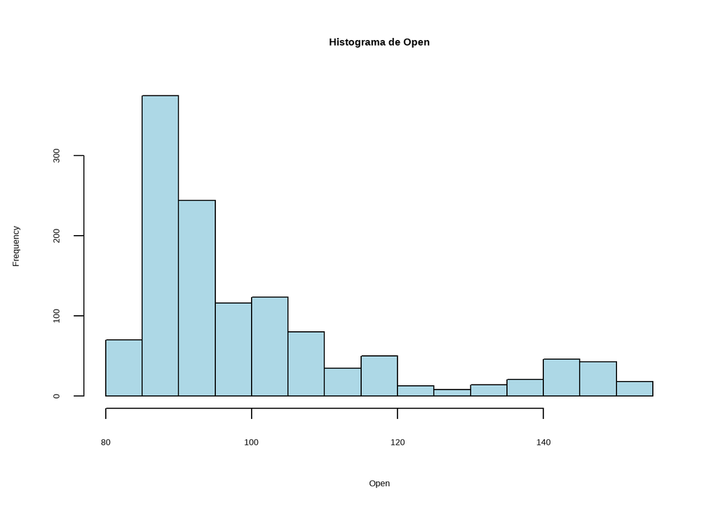

```r
hist(tlt$Open,
     main = "Histograma de Open",
     xlab = "Open",
     col = "lightblue",
     border = "black")
```

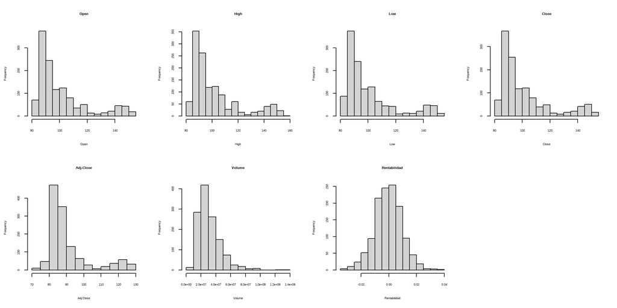

```r
par(mfrow = c(2, 4))

hist(tlt$Open, main = "Open", xlab = "Open")
hist(tlt$High, main = "High", xlab = "High")
hist(tlt$Low, main = "Low", xlab = "Low")
hist(tlt$Close, main = "Close", xlab = "Close")
hist(tlt$Adj.Close, main = "Adj.Close", xlab = "Adj.Close")
hist(tlt$Volume, main = "Volume", xlab = "Volume")
hist(tlt$rentabilidad, main = "Rentabilidad", xlab = "Rentabilidad")

par(mfrow = c(1, 1))
```

### Índice del dólar (DX-Y.NYB)

```r
dolar <- read.csv("datos_csv/DOLAR.csv")
pander::pander(head(dolar,10))
```

| Date | Open | High | Low | Close | Adj.Close | Volume |
| --- | --- | --- | --- | --- | --- | --- |
| 2021-09-07 | 92.2 | 92.57 | 92.1 | 92.52 | 92.52 | 0 |
| 2021-09-08 | 92.54 | 92.86 | 92.47 | 92.65 | 92.65 | 0 |
| 2021-09-09 | 92.71 | 92.76 | 92.38 | 92.48 | 92.48 | 0 |
| 2021-09-10 | 92.53 | 92.65 | 92.33 | 92.58 | 92.58 | 0 |
| 2021-09-13 | 92.61 | 92.89 | 92.57 | 92.62 | 92.62 | 0 |
| 2021-09-14 | 92.62 | 92.68 | 92.32 | 92.65 | 92.65 | 0 |
| 2021-09-15 | 92.68 | 92.68 | 92.42 | 92.49 | 92.49 | 0 |
| 2021-09-16 | 92.46 | 92.96 | 92.46 | 92.86 | 92.86 | 0 |
| 2021-09-17 | 92.88 | 93.25 | 92.77 | 93.2 | 93.2 | 0 |
| 2021-09-20 | 93.25 | 93.45 | 93.19 | 93.24 | 93.24 | 0 |

creamos la rentabilidad del periodo calculada como:

$$rentabilidad =
Ln\left(\frac{C_t}{C_{t-1}}\right)$$

```r
dolar <- dolar |>
  mutate(
    rentabilidad = log(Close / lag(Close))
  )
dolar <- dolar |>
  mutate(
    rent_porcent = round(rentabilidad*100,4)
  )
```

posteriormente de este analisis vamos a realizar el analisis exploratorio de la base.

```r
pander(diagnose(dolar))
```

Table continues below

| variables | types | missing_count | missing_percent | unique_count |
| --- | --- | --- | --- | --- |
| Date | character | 0 | 0 | 1257 |
| Open | numeric | 0 | 0 | 818 |
| High | numeric | 0 | 0 | 833 |
| Low | numeric | 0 | 0 | 805 |
| Close | numeric | 0 | 0 | 826 |
| Adj.Close | numeric | 0 | 0 | 826 |
| Volume | integer | 0 | 0 | 1 |
| rentabilidad | numeric | 1 | 0.07955 | 1239 |
| rent_porcent | numeric | 1 | 0.07955 | 1167 |

| unique_rate |
| --- |
| 1 |
| 0.6508 |
| 0.6627 |
| 0.6404 |
| 0.6571 |
| 0.6571 |
| 0.0007955 |
| 0.9857 |
| 0.9284 |

```r
pander(diagnose_outlier(dolar))
```

Table continues below

| variables | outliers_cnt | outliers_ratio | outliers_mean | with_mean |
| --- | --- | --- | --- | --- |
| Open | 5 | 0.3978 | 113.6 | 102 |
| High | 6 | 0.4773 | 114.2 | 102.4 |
| Low | 3 | 0.2387 | 113.1 | 101.7 |
| Close | 4 | 0.3182 | 113.7 | 102 |
| Adj.Close | 4 | 0.3182 | 113.7 | 102 |
| Volume | 0 | 0 | NA | 0 |
| rentabilidad | 38 | 3.023 | -0.005698 | 5.518e-05 |
| rent_porcent | 38 | 3.023 | -0.5698 | 0.005519 |

| without_mean |
| --- |
| 102 |
| 102.3 |
| 101.7 |
| 102 |
| 102 |
| 0 |
| 0.0002347 |
| 0.02347 |

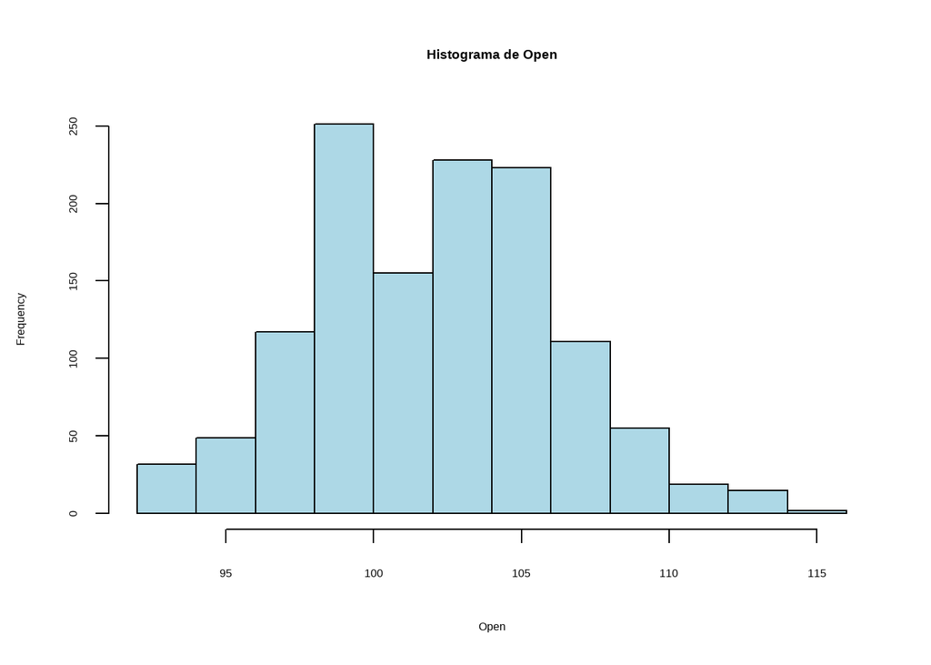

```r
hist(dolar$Open,
     main = "Histograma de Open",
     xlab = "Open",
     col = "lightblue",
     border = "black")
```

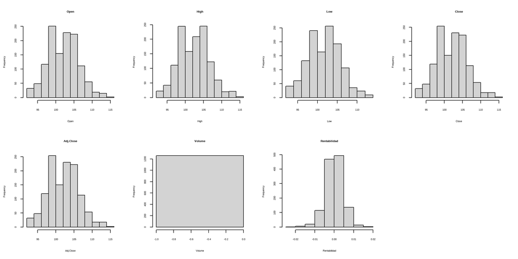

```r
par(mfrow = c(2, 4))

hist(dolar$Open, main = "Open", xlab = "Open")
hist(dolar$High, main = "High", xlab = "High")
hist(dolar$Low, main = "Low", xlab = "Low")
hist(dolar$Close, main = "Close", xlab = "Close")
hist(dolar$Adj.Close, main = "Adj.Close", xlab = "Adj.Close")
hist(dolar$Volume, main = "Volume", xlab = "Volume")
hist(dolar$rentabilidad, main = "Rentabilidad", xlab = "Rentabilidad")

par(mfrow = c(1, 1))
```

### Euro (FXE)

```r
euro <- read.csv("datos_csv/EURO.csv")
pander::pander(head(euro,10))
```

| Date | Open | High | Low | Close | Adj.Close | Volume |
| --- | --- | --- | --- | --- | --- | --- |
| 2021-09-07 | 110.5 | 110.6 | 110.4 | 110.4 | 104.7 | 32900 |
| 2021-09-08 | 110.2 | 110.3 | 110.1 | 110.2 | 104.5 | 84200 |
| 2021-09-09 | 110.3 | 110.4 | 110.1 | 110.3 | 104.6 | 71400 |
| 2021-09-10 | 110.3 | 110.4 | 110.1 | 110.1 | 104.4 | 64000 |
| 2021-09-13 | 110 | 110.2 | 110 | 110.1 | 104.4 | 39200 |
| 2021-09-14 | 110.4 | 110.4 | 110 | 110.1 | 104.4 | 35900 |
| 2021-09-15 | 110.2 | 110.2 | 110.1 | 110.2 | 104.5 | 22900 |
| 2021-09-16 | 109.6 | 109.8 | 109.6 | 109.7 | 104.1 | 52400 |
| 2021-09-17 | 109.6 | 109.7 | 109.3 | 109.4 | 103.7 | 256900 |
| 2021-09-20 | 109.2 | 109.4 | 109.2 | 109.4 | 103.7 | 163100 |

creamos la rentabilidad del periodo calculada como:

$$rentabilidad =
Ln\left(\frac{C_t}{C_{t-1}}\right)$$

```r
euro <- euro |>
  mutate(
    rentabilidad = log(Close / lag(Close))
  )
euro <- euro |>
  mutate(
    rent_porcent = round(rentabilidad*100,4)
  )
```

posteriormente de este analisis vamos a realizar el analisis exploratorio de la base.

```r
pander(diagnose(euro))
```

Table continues below

| variables | types | missing_count | missing_percent | unique_count |
| --- | --- | --- | --- | --- |
| Date | character | 0 | 0 | 1255 |
| Open | numeric | 0 | 0 | 852 |
| High | numeric | 0 | 0 | 823 |
| Low | numeric | 0 | 0 | 855 |
| Close | numeric | 0 | 0 | 836 |
| Adj.Close | numeric | 0 | 0 | 1181 |
| Volume | integer | 0 | 0 | 915 |
| rentabilidad | numeric | 1 | 0.07968 | 1239 |
| rent_porcent | numeric | 1 | 0.07968 | 1171 |

| unique_rate |
| --- |
| 1 |
| 0.6789 |
| 0.6558 |
| 0.6813 |
| 0.6661 |
| 0.941 |
| 0.7291 |
| 0.9873 |
| 0.9331 |

```r
pander(diagnose_outlier(euro))
```

Table continues below

| variables | outliers_cnt | outliers_ratio | outliers_mean | with_mean |
| --- | --- | --- | --- | --- |
| Open | 0 | 0 | NA | 101.8 |
| High | 0 | 0 | NA | 102 |
| Low | 0 | 0 | NA | 101.6 |
| Close | 0 | 0 | NA | 101.8 |
| Adj.Close | 0 | 0 | NA | 98.75 |
| Volume | 100 | 7.968 | 438004 | 109551 |
| rentabilidad | 37 | 2.948 | 0.003008 | -2.412e-05 |
| rent_porcent | 37 | 2.948 | 0.3008 | -0.002411 |

| without_mean |
| --- |
| 101.8 |
| 102 |
| 101.6 |
| 101.8 |
| 98.75 |
| 81113 |
| -0.0001163 |
| -0.01163 |

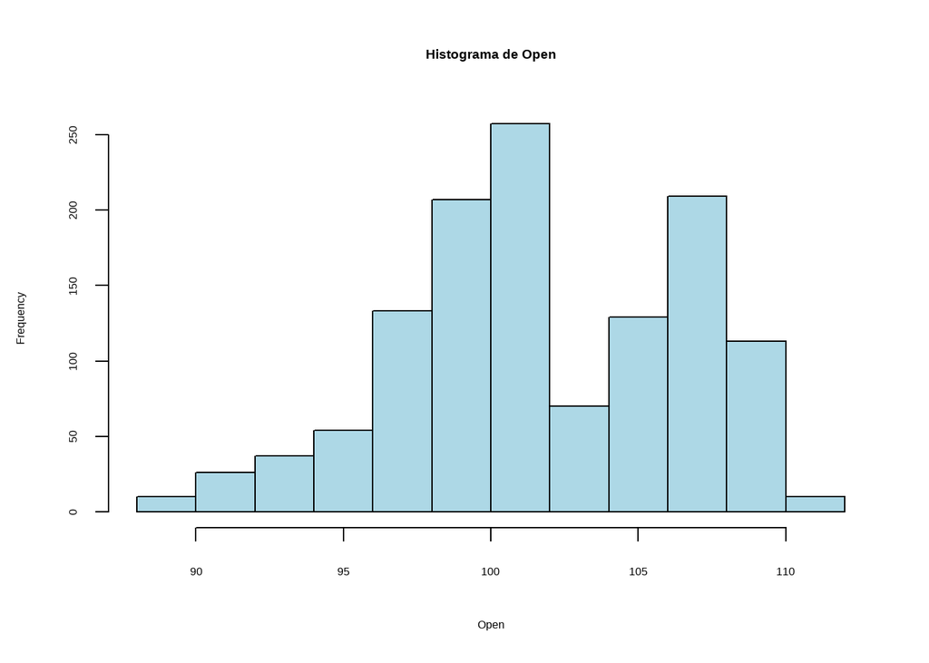

```r
hist(euro$Open,
     main = "Histograma de Open",
     xlab = "Open",
     col = "lightblue",
     border = "black")
```

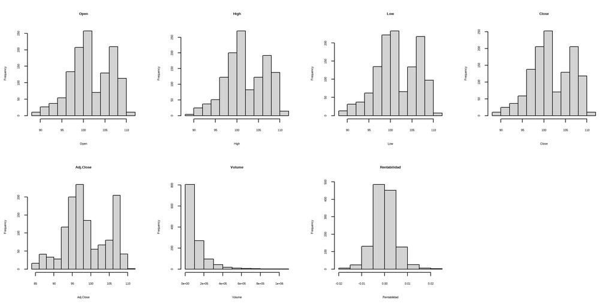

```r
par(mfrow = c(2, 4))

hist(euro$Open, main = "Open", xlab = "Open")
hist(euro$High, main = "High", xlab = "High")
hist(euro$Low, main = "Low", xlab = "Low")
hist(euro$Close, main = "Close", xlab = "Close")
hist(euro$Adj.Close, main = "Adj.Close", xlab = "Adj.Close")
hist(euro$Volume, main = "Volume", xlab = "Volume")
hist(euro$rentabilidad, main = "Rentabilidad", xlab = "Rentabilidad")

par(mfrow = c(1, 1))
```

### Bitcoin (BTC-USD)

```r
btc <- read.csv("datos_csv/BTC.csv")
pander::pander(head(btc,10))
```

| Date | Open | High | Low | Close | Adj.Close | Volume |
| --- | --- | --- | --- | --- | --- | --- |
| 2021-09-04 | 50009 | 50546 | 49549 | 49945 | 49945 | 3.747e+10 |
| 2021-09-05 | 49938 | 51869 | 49539 | 51753 | 51753 | 3.032e+10 |
| 2021-09-06 | 51769 | 52701 | 51054 | 52634 | 52634 | 3.888e+10 |
| 2021-09-07 | 52660 | 52854 | 43285 | 46811 | 46811 | 6.521e+10 |
| 2021-09-08 | 46828 | 47334 | 44561 | 46091 | 46091 | 4.901e+10 |
| 2021-09-09 | 45775 | 47262 | 45670 | 46391 | 46391 | 3.867e+10 |
| 2021-09-10 | 46397 | 47032 | 44344 | 44884 | 44884 | 3.915e+10 |
| 2021-09-11 | 44870 | 45969 | 44818 | 45201 | 45201 | 3.45e+10 |
| 2021-09-12 | 45207 | 46365 | 44790 | 46063 | 46063 | 2.788e+10 |
| 2021-09-13 | 46057 | 46599 | 43591 | 44963 | 44963 | 4.097e+10 |

creamos la rentabilidad del periodo calculada como:

$$rentabilidad =
Ln\left(\frac{C_t}{C_{t-1}}\right)$$

```r
btc <- btc |>
  mutate(
    rentabilidad = log(Close / lag(Close))
  )
btc <- btc |>
  mutate(
    rent_porcent = round(rentabilidad*100,4)
  )
```

posteriormente de este analisis vamos a realizar el analisis exploratorio de la base.

```r
pander(diagnose(btc))
```

Table continues below

| variables | types | missing_count | missing_percent | unique_count |
| --- | --- | --- | --- | --- |
| Date | character | 0 | 0 | 1827 |
| Open | numeric | 0 | 0 | 1827 |
| High | numeric | 0 | 0 | 1827 |
| Low | numeric | 0 | 0 | 1826 |
| Close | numeric | 0 | 0 | 1827 |
| Adj.Close | numeric | 0 | 0 | 1827 |
| Volume | numeric | 0 | 0 | 1827 |
| rentabilidad | numeric | 1 | 0.05473 | 1827 |
| rent_porcent | numeric | 1 | 0.05473 | 1803 |

| unique_rate |
| --- |
| 1 |
| 1 |
| 1 |
| 0.9995 |
| 1 |
| 1 |
| 1 |
| 1 |
| 0.9869 |

```r
pander(diagnose_outlier(btc))
```

Table continues below

| variables | outliers_cnt | outliers_ratio | outliers_mean | with_mean |
| --- | --- | --- | --- | --- |
| Open | 0 | 0 | NA | 58165 |
| High | 0 | 0 | NA | 59193 |
| Low | 0 | 0 | NA | 57081 |
| Close | 0 | 0 | NA | 58179 |
| Adj.Close | 0 | 0 | NA | 58179 |
| Volume | 81 | 4.433 | 9.714e+10 | 3.48e+10 |
| rentabilidad | 122 | 6.678 | -0.005067 | 0.0002558 |
| rent_porcent | 122 | 6.678 | -0.5067 | 0.02557 |

| without_mean |
| --- |
| 58165 |
| 59193 |
| 57081 |
| 58179 |
| 58179 |
| 3.19e+10 |
| 0.0006368 |
| 0.06368 |

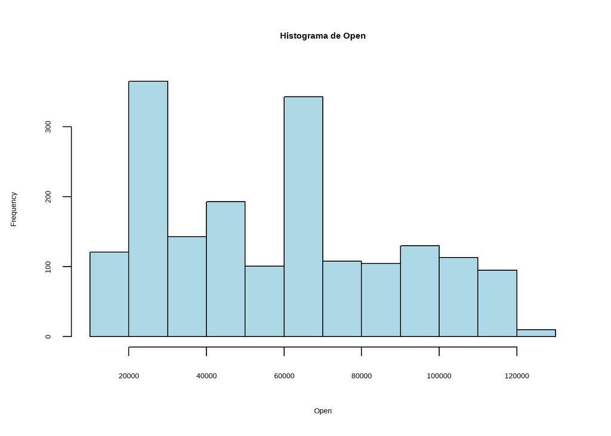

```r
hist(btc$Open,
     main = "Histograma de Open",
     xlab = "Open",
     col = "lightblue",
     border = "black")
```

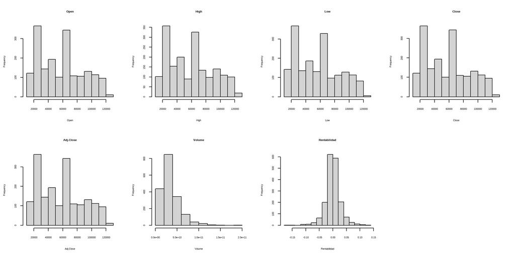

```r
par(mfrow = c(2, 4))

hist(btc$Open, main = "Open", xlab = "Open")
hist(btc$High, main = "High", xlab = "High")
hist(btc$Low, main = "Low", xlab = "Low")
hist(btc$Close, main = "Close", xlab = "Close")
hist(btc$Adj.Close, main = "Adj.Close", xlab = "Adj.Close")
hist(btc$Volume, main = "Volume", xlab = "Volume")
hist(btc$rentabilidad, main = "Rentabilidad", xlab = "Rentabilidad")

par(mfrow = c(1, 1))
```